# Socioeconomic Determinants of Depression & Diabetes Using NHANES (2017–2020)

Nick Hollman

2025-05-05

Import libraries for analysis

Load Datasets

```r
setwd("C:\\Users\\nickd\\OneDrive\\RProj\\NHANES\\")
demo <- read_xpt("P_DEMO.xpt")
health_ins <- read_xpt("P_HIQ.xpt")
food_sec <- read_xpt("P_FSQ.xpt")
occupation <- read_xpt("P_OCQ.xpt")
alcohol <- read_xpt("P_ALQ.xpt")
smoke <- read_xpt("P_SMQ.xpt")
sedentary <- read_xpt("P_PAQ.xpt")
diabetes <- read_xpt("P_DIQ.xpt")
depression <- read_xpt("P_DPQ.xpt")
```

Limit Data to only variables needed for analysis

```r
demo_ <- demo %>% select(SEQN, RIAGENDR, RIDAGEYR, RIDRETH3, DMDEDUC2, INDFMPIR, DMDMARTZ, DMDBORN4, DMDYRUSZ)
health_ins_ <- health_ins %>% select(SEQN, HIQ011)
food_sec_ <- food_sec %>% select(SEQN, FSDHH)
occupation_ <- occupation %>% select(SEQN, OCD150, OCQ180, OCQ210)
alcohol_ <- alcohol %>% select(SEQN, ALQ111, ALQ121)
smoke_ <- smoke %>% select(SEQN, SMQ020, SMQ040)
sedentary_ <- sedentary %>% select(SEQN, PAD680)
diabetes_ <- diabetes %>% select(SEQN, DIQ010)
depression_ <- depression %>% select(SEQN, DPQ010, DPQ020, DPQ030, DPQ040, DPQ050, DPQ060, DPQ070, DPQ080, DPQ090)
```

Drop original datasets

```r
rm("alcohol", "demo", "depression", "diabetes", "food_sec", "health_ins", "occupation", "sedentary", "smoke")
```

Data prep (recoding of variables, etc.)

```r
freq(alcohol_$ALQ121)
```

```
## Frequencies
## alcohol_$ALQ121
## Label: Past 12 mo how often drink alcoholic bev
## Type: Numeric
##
##               Freq   % Valid   % Valid Cum.   % Total   % Total Cum.
## ----------- ------ --------- -------------- --------- --------------
##           0   1638    21.831         21.831    18.271         18.271
##           1    240     3.199         25.030     2.677         20.948
##           2    273     3.639         28.669     3.045         23.993
##           3    514     6.851         35.519     5.733         29.727
##           4    586     7.810         43.329     6.537         36.263
##           5    562     7.490         50.820     6.269         42.532
##           6   1042    13.888         64.707    11.623         54.155
##           7    570     7.597         72.304     6.358         60.513
##           8    457     6.091         78.395     5.098         65.611
##           9    795    10.596         88.991     8.868         74.479
##          10    822    10.956         99.947     9.169         83.648
##          77      2     0.027         99.973     0.022         83.670
##          99      2     0.027        100.000     0.022         83.692
##        <NA>   1462                             16.308        100.000
##       Total   8965   100.000        100.000   100.000        100.000
```

Recode as follows to capture current drinker: IF ALQ121 >= 1 & <= 10 THEN Current_drink = 1, ELSE IF ALQ121==0 THEN Current_drink = 0, ELSE IF ALQ121==77 OR ALQ121==99 THEN Current_drink = missing ELSE Current_drink = missing

```r
alcohol_recode <- alcohol_ %>% mutate(Current_drink = case_when(
                                         ALQ121 >= 1 & ALQ121 <= 10 ~ 1,
                                         ALQ121==0 ~ 0,
                                         ALQ121==77 | ALQ121 ==99 ~ NA_real_,
                                         TRUE ~ NA_real_))
freq(alcohol_recode$Current_drink)
```

```
## Frequencies
## alcohol_recode$Current_drink
## Type: Numeric
##
##               Freq   % Valid   % Valid Cum.   % Total   % Total Cum.
## ----------- ------ --------- -------------- --------- --------------
##           0   1638     21.84          21.84     18.27          18.27
##           1   5861     78.16         100.00     65.38          83.65
##        <NA>   1466                              16.35         100.00
##       Total   8965    100.00         100.00    100.00         100.00
```

Do we need to recode gender? Yes, recategorize female to 0 opposed to 2

```r
freq(demo_$RIAGENDR)
```

```
## Frequencies
## demo_$RIAGENDR
## Label: Gender
## Type: Numeric
##
##                Freq   % Valid   % Valid Cum.   % Total   % Total Cum.
## ----------- ------- --------- -------------- --------- --------------
##           1    7721     49.62          49.62     49.62          49.62
##           2    7839     50.38         100.00     50.38         100.00
##        <NA>       0                               0.00         100.00
##       Total   15560    100.00         100.00    100.00         100.00
```

```r
demo_recode <- demo_ %>% mutate(gender = if_else(RIAGENDR==2, 0, 1))
freq(demo_recode$gender)
```

```
## Frequencies
## demo_recode$gender
## Type: Numeric
##
##                Freq   % Valid   % Valid Cum.   % Total   % Total Cum.
## ----------- ------- --------- -------------- --------- --------------
##           0    7839     50.38          50.38     50.38          50.38
##           1    7721     49.62         100.00     49.62         100.00
##        <NA>       0                               0.00         100.00
##       Total   15560    100.00         100.00    100.00         100.00
```

Limit to age 20+ (I only want to analyze adults), adjust to categories due to NHANES setting upper limit of age to 80

```r
freq(demo_$RIDAGEYR)
```

```
## Frequencies
## demo_$RIDAGEYR
## Label: Age in years at screening
## Type: Numeric
##
##                Freq   % Valid   % Valid Cum.   % Total   % Total Cum.
## ----------- ------- --------- -------------- --------- --------------
##           0     574      3.69           3.69      3.69           3.69
##           1     406      2.61           6.30      2.61           6.30
##           2     431      2.77           9.07      2.77           9.07
##           3     312      2.01          11.07      2.01          11.07
##           4     302      1.94          13.01      1.94          13.01
##           5     317      2.04          15.05      2.04          15.05
##           6     300      1.93          16.98      1.93          16.98
##           7     310      1.99          18.97      1.99          18.97
```

[output cut: 75 more lines]

```r
describe(demo_$RIDAGEYR)
```

```
##    vars     n  mean    sd median trimmed   mad min max range skew kurtosis  se
## X1    1 15560 33.74 25.32     30   32.44 32.62   0  80    80 0.31    -1.26 0.2
```

```r
demo_adult <- demo_ %>% filter(RIDAGEYR >= 20)
demo_recode_adult <- demo_recode %>% filter(RIDAGEYR >= 20)
demo_recode_adult <- demo_recode_adult %>% mutate(age_cat = case_when(
                                         RIDAGEYR >= 20 & RIDAGEYR < 30 ~ 0,
                                         RIDAGEYR >= 30 & RIDAGEYR < 40 ~ 1,
                                         RIDAGEYR >= 40 & RIDAGEYR < 50 ~ 2,
                                         RIDAGEYR >= 50 & RIDAGEYR < 60 ~ 3,
                                         RIDAGEYR >= 60 & RIDAGEYR < 70 ~ 4,
                                         RIDAGEYR >= 70 & RIDAGEYR <= 80 ~ 5))
freq(demo_recode_adult$age_cat)
```

```
## Frequencies
## demo_recode_adult$age_cat
## Type: Numeric
##
##               Freq   % Valid   % Valid Cum.   % Total   % Total Cum.
## ----------- ------ --------- -------------- --------- --------------
##           0   1378     14.93          14.93     14.93          14.93
##           1   1421     15.39          30.32     15.39          30.32
##           2   1446     15.66          45.98     15.66          45.98
##           3   1565     16.95          62.93     16.95          62.93
##           4   1746     18.91          81.85     18.91          81.85
##           5   1676     18.15         100.00     18.15         100.00
##        <NA>      0                               0.00         100.00
##       Total   9232    100.00         100.00    100.00         100.00
```

Do we need to recode race? No, all have over 400 observations

```r
freq(demo_recode_adult$RIDRETH3)
```

```
## Frequencies
## demo_recode_adult$RIDRETH3
## Label: Race/Hispanic origin w/ NH Asian
## Type: Numeric
##
##               Freq   % Valid   % Valid Cum.   % Total   % Total Cum.
## ----------- ------ --------- -------------- --------- --------------
##           1   1057     11.45          11.45     11.45          11.45
##           2    940     10.18          21.63     10.18          21.63
##           3   3217     34.85          56.48     34.85          56.48
##           4   2459     26.64          83.11     26.64          83.11
##           6   1120     12.13          95.24     12.13          95.24
##           7    439      4.76         100.00      4.76         100.00
##        <NA>      0                               0.00         100.00
##       Total   9232    100.00         100.00    100.00         100.00
```

Do we need to recode education? Yes, recode 7 & 9 to missing

```r
freq(demo_recode_adult$DMDEDUC2)
```

```
## Frequencies
## demo_recode_adult$DMDEDUC2
## Label: Education level - Adults 20+
## Type: Numeric
##
##               Freq   % Valid   % Valid Cum.   % Total   % Total Cum.
## ----------- ------ --------- -------------- --------- --------------
##           1    719     7.788          7.788     7.788          7.788
##           2   1041    11.276         19.064    11.276         19.064
##           3   2225    24.101         43.165    24.101         43.165
##           4   2975    32.225         75.390    32.225         75.390
##           5   2257    24.448         99.838    24.448         99.838
##           7      2     0.022         99.859     0.022         99.859
##           9     13     0.141        100.000     0.141        100.000
##        <NA>      0                              0.000        100.000
##       Total   9232   100.000        100.000   100.000        100.000
```

```r
demo_recode_adult <- demo_recode_adult %>% mutate(educat = if_else(DMDEDUC2==7 | DMDEDUC2==9, NA_real_, DMDEDUC2))
freq(demo_recode_adult$educat)
```

```
## Frequencies
## demo_recode_adult$educat
## Type: Numeric
##
##               Freq   % Valid   % Valid Cum.   % Total   % Total Cum.
## ----------- ------ --------- -------------- --------- --------------
##           1    719      7.80           7.80      7.79           7.79
##           2   1041     11.29          19.10     11.28          19.06
##           3   2225     24.14          43.24     24.10          43.17
##           4   2975     32.28          75.51     32.22          75.39
##           5   2257     24.49         100.00     24.45          99.84
##        <NA>     15                               0.16         100.00
##       Total   9232    100.00         100.00    100.00         100.00
```

Bin poverty to income ratio - <= 1.30, 1.31–1.85, 1.86–3.5, and >3.5, <= 1.30 is indicative of potential eligibility for SNAP (https://doi.org/10.1093/ajcn/nqab113) - > 3.5 is the reference group

```r
freq(demo_recode_adult$INDFMPIR)
```

```
## Frequencies
## demo_recode_adult$INDFMPIR
## Label: Ratio of family income to poverty
## Type: Numeric
##
##               Freq   % Valid   % Valid Cum.   % Total   % Total Cum.
## ----------- ------ --------- -------------- --------- --------------
##           0     62     0.792          0.792     0.672          0.672
##        0.01      4     0.051          0.843     0.043          0.715
##        0.02      4     0.051          0.894     0.043          0.758
##        0.03      8     0.102          0.996     0.087          0.845
##        0.04     20     0.255          1.252     0.217          1.062
##        0.05     10     0.128          1.380     0.108          1.170
##        0.06     12     0.153          1.533     0.130          1.300
##        0.07      9     0.115          1.648     0.097          1.397
##        0.08      8     0.102          1.750     0.087          1.484
##        0.09     11     0.141          1.891     0.119          1.603
##         0.1     20     0.255          2.146     0.217          1.820
##        0.11      1     0.013          2.159     0.011          1.831
##        0.12     19     0.243          2.402     0.206          2.036
##        0.13      1     0.013          2.414     0.011          2.047
##        0.14      2     0.026          2.440     0.022          2.069
##        0.15      6     0.077          2.517     0.065          2.134
##        0.16      6     0.077          2.593     0.065          2.199
##        0.17      7     0.089          2.683     0.076          2.275
##        0.18      7     0.089          2.772     0.076          2.351
##        0.19      5     0.064          2.836     0.054          2.405
##         0.2      9     0.115          2.951     0.097          2.502
##        0.21     12     0.153          3.104     0.130          2.632
##        0.23      5     0.064          3.168     0.054          2.686
##        0.24      6     0.077          3.245     0.065          2.751
##        0.25     18     0.230          3.475     0.195          2.946
##        0.26      3     0.038          3.513     0.032          2.979
##        0.27      2     0.026          3.539     0.022          3.000
##        0.28     13     0.166          3.705     0.141          3.141
##        0.29     13     0.166          3.871     0.141          3.282
##         0.3      6     0.077          3.947     0.065          3.347
##        0.31      8     0.102          4.050     0.087          3.434
##        0.32      7     0.089          4.139     0.076          3.510
##        0.33     10     0.128          4.267     0.108          3.618
```

[output cut: 424 more lines]

```
##        4.83      1     0.013         80.187     0.011         67.992
##        4.85      8     0.102         80.289     0.087         68.078
##        4.86     18     0.230         80.519     0.195         68.273
##        4.88      2     0.026         80.544     0.022         68.295
##        4.89      1     0.013         80.557     0.011         68.306
##         4.9      9     0.115         80.672     0.097         68.403
##        4.91      6     0.077         80.749     0.065         68.468
##        4.93     25     0.319         81.068     0.271         68.739
##        4.94      2     0.026         81.094     0.022         68.761
##        4.96      2     0.026         81.119     0.022         68.782
##        4.97      5     0.064         81.183     0.054         68.837
##        4.98     10     0.128         81.311     0.108         68.945
##           5   1463    18.689        100.000    15.847         84.792
##        <NA>   1404                             15.208        100.000
##       Total   9232   100.000        100.000   100.000        100.000
```

```r
describe(demo_recode_adult$INDFMPIR)
```

```
##    vars    n mean   sd median trimmed  mad min max range skew kurtosis   se
## X1    1 7828  2.6 1.63   2.21    2.58 1.88   0   5     5 0.28    -1.33 0.02
```

```r
demo_recode_adult <- demo_recode_adult %>% mutate(PIR_cat = case_when(
                                         INDFMPIR > 3.5 ~ 0,
                                         INDFMPIR >= 1.86 & INDFMPIR <= 3.5 ~ 1,
                                         INDFMPIR >= 1.31 & INDFMPIR <= 1.85 ~ 2,
                                         INDFMPIR <= 1.30 ~ 3,
                                         TRUE ~ NA_real_))
freq(demo_recode_adult$PIR_cat)
```

```
## Frequencies
## demo_recode_adult$PIR_cat
## Type: Numeric
##
##               Freq   % Valid   % Valid Cum.   % Total   % Total Cum.
## ----------- ------ --------- -------------- --------- --------------
##           0   2531     32.33          32.33     27.42          27.42
##           1   1936     24.73          57.06     20.97          48.39
##           2   1143     14.60          71.67     12.38          60.77
##           3   2218     28.33         100.00     24.03          84.79
##        <NA>   1404                              15.21         100.00
##       Total   9232    100.00         100.00    100.00         100.00
```

Do we need to recode marital status? Yes, recode Refused or Don’t know to missing

```r
freq(demo_recode_adult$DMDMARTZ)
```

```
## Frequencies
## demo_recode_adult$DMDMARTZ
## Label: Marital status
## Type: Numeric
##
##               Freq   % Valid   % Valid Cum.   % Total   % Total Cum.
## ----------- ------ --------- -------------- --------- --------------
##           1   5279    57.182         57.182    57.182         57.182
##           2   2148    23.267         80.448    23.267         80.448
##           3   1795    19.443         99.892    19.443         99.892
##          77      8     0.087         99.978     0.087         99.978
##          99      2     0.022        100.000     0.022        100.000
##        <NA>      0                              0.000        100.000
##       Total   9232   100.000        100.000   100.000        100.000
```

```r
demo_recode_adult <- demo_recode_adult %>% mutate(Marriage = if_else(DMDMARTZ==77 | DMDMARTZ==99, NA_real_, DMDMARTZ))
freq(demo_recode_adult$Marriage)
```

```
## Frequencies
## demo_recode_adult$Marriage
## Type: Numeric
##
##               Freq   % Valid   % Valid Cum.   % Total   % Total Cum.
## ----------- ------ --------- -------------- --------- --------------
##           1   5279     57.24          57.24     57.18          57.18
##           2   2148     23.29          80.54     23.27          80.45
##           3   1795     19.46         100.00     19.44          99.89
##        <NA>     10                               0.11         100.00
##       Total   9232    100.00         100.00    100.00         100.00
```

Do we need to recode US born? Yes, recode Refused or Don’t know to missing, subtract 1 so US born is reference 0 vs born outside the US = 1

```r
freq(demo_recode_adult$DMDBORN4)
```

```
## Frequencies
## demo_recode_adult$DMDBORN4
## Label: Country of birth
## Type: Numeric
##
##               Freq   % Valid   % Valid Cum.   % Total   % Total Cum.
## ----------- ------ --------- -------------- --------- --------------
##           1   6561    71.068         71.068    71.068         71.068
##           2   2666    28.878         99.946    28.878         99.946
##          77      4     0.043         99.989     0.043         99.989
##          99      1     0.011        100.000     0.011        100.000
##        <NA>      0                              0.000        100.000
##       Total   9232   100.000        100.000   100.000        100.000
```

```r
demo_recode_adult <- demo_recode_adult %>% mutate(US_born = if_else(DMDBORN4==77 | DMDBORN4==99, NA_real_, DMDBORN4))
demo_recode_adult <- demo_recode_adult %>% mutate(US_born = US_born - 1)
freq(demo_recode_adult$US_born)
```

```
## Frequencies
## demo_recode_adult$US_born
## Type: Numeric
##
##               Freq   % Valid   % Valid Cum.   % Total   % Total Cum.
## ----------- ------ --------- -------------- --------- --------------
##           0   6561    71.107         71.107    71.068         71.068
##           1   2666    28.893        100.000    28.878         99.946
##        <NA>      5                              0.054        100.000
##       Total   9232   100.000        100.000   100.000        100.000
```

Do we need to recode number of years in the US? Recode 77 and 99 to missing

```r
freq(demo_recode_adult$DMDYRUSZ)
```

```
## Frequencies
## demo_recode_adult$DMDYRUSZ
## Label: Length of time in US
## Type: Numeric
##
##               Freq   % Valid   % Valid Cum.   % Total   % Total Cum.
## ----------- ------ --------- -------------- --------- --------------
##           1    308     11.55          11.55      3.34           3.34
##           2    469     17.59          29.14      5.08           8.42
##           3    906     33.98          63.13      9.81          18.23
##           4    864     32.41          95.54      9.36          27.59
##          77     33      1.24          96.77      0.36          27.95
##          99     86      3.23         100.00      0.93          28.88
##        <NA>   6566                              71.12         100.00
##       Total   9232    100.00         100.00    100.00         100.00
```

```r
describe(demo_recode_adult$DMDYRUSZ)
```

```
##    vars    n mean    sd median trimmed  mad min max range skew kurtosis   se
## X1    1 2666 6.93 18.73      3    3.08 1.48   1  99    98 4.47    18.27 0.36
```

```r
demo_recode_adult <- demo_recode_adult %>% mutate(US_time = if_else(DMDYRUSZ==77 | DMDYRUSZ==99, NA_real_, DMDYRUSZ))
freq(demo_recode_adult$US_time)
```

```
## Frequencies
## demo_recode_adult$US_time
## Type: Numeric
##
##               Freq   % Valid   % Valid Cum.   % Total   % Total Cum.
## ----------- ------ --------- -------------- --------- --------------
##           1    308     12.09          12.09      3.34           3.34
##           2    469     18.41          30.51      5.08           8.42
##           3    906     35.57          66.08      9.81          18.23
##           4    864     33.92         100.00      9.36          27.59
##        <NA>   6685                              72.41         100.00
##       Total   9232    100.00         100.00    100.00         100.00
```

Initial depression screener responses

```r
freq(depression_$DPQ010)
```

```
## Frequencies
## depression_$DPQ010
## Label: Have little interest in doing things
## Type: Numeric
##
##               Freq   % Valid   % Valid Cum.   % Total   % Total Cum.
## ----------- ------ --------- -------------- --------- --------------
##           0   6166    74.218         74.218    68.779         68.779
##           1   1372    16.514         90.732    15.304         84.083
##           2    450     5.416         96.148     5.020         89.102
##           3    310     3.731         99.880     3.458         92.560
##           7      4     0.048         99.928     0.045         92.605
##           9      6     0.072        100.000     0.067         92.672
##        <NA>    657                              7.328        100.000
##       Total   8965   100.000        100.000   100.000        100.000
```

```r
freq(depression_$DPQ020)
```

```
## Frequencies
## depression_$DPQ020
## Label: Feeling down, depressed, or hopeless
## Type: Numeric
##
##               Freq   % Valid   % Valid Cum.   % Total   % Total Cum.
## ----------- ------ --------- -------------- --------- --------------
##           0   6187    74.488         74.488    69.013         69.013
##           1   1456    17.529         92.018    16.241         85.254
##           2    387     4.659         96.677     4.317         89.571
##           3    269     3.239         99.916     3.001         92.571
##           7      2     0.024         99.940     0.022         92.593
##           9      5     0.060        100.000     0.056         92.649
##        <NA>    659                              7.351        100.000
##       Total   8965   100.000        100.000   100.000        100.000
```

```r
freq(depression_$DPQ030)
```

```
## Frequencies
## depression_$DPQ030
## Label: Trouble sleeping or sleeping too much
## Type: Numeric
##
##               Freq   % Valid   % Valid Cum.   % Total   % Total Cum.
## ----------- ------ --------- -------------- --------- --------------
##           0   5023    60.474         60.474    56.029         56.029
##           1   1890    22.755         83.229    21.082         77.111
##           2    621     7.477         90.706     6.927         84.038
##           3    764     9.198         99.904     8.522         92.560
##           7      3     0.036         99.940     0.033         92.593
##           9      5     0.060        100.000     0.056         92.649
##        <NA>    659                              7.351        100.000
##       Total   8965   100.000        100.000   100.000        100.000
```

```r
freq(depression_$DPQ040)
```

```
## Frequencies
## depression_$DPQ040
## Label: Feeling tired or having little energy
## Type: Numeric
##
##               Freq   % Valid   % Valid Cum.   % Total   % Total Cum.
## ----------- ------ --------- -------------- --------- --------------
##           0   4164    50.138         50.138    46.447         46.447
##           1   2682    32.294         82.432    29.916         76.364
##           2    754     9.079         91.511     8.410         84.774
##           3    697     8.393         99.904     7.775         92.549
##           7      4     0.048         99.952     0.045         92.593
##           9      4     0.048        100.000     0.045         92.638
##        <NA>    660                              7.362        100.000
##       Total   8965   100.000        100.000   100.000        100.000
```

```r
freq(depression_$DPQ050)
```

```
## Frequencies
## depression_$DPQ050
## Label: Poor appetite or overeating
## Type: Numeric
##
##               Freq   % Valid   % Valid Cum.   % Total   % Total Cum.
## ----------- ------ --------- -------------- --------- --------------
##           0   6165    74.232         74.232    68.767         68.767
##           1   1293    15.569         89.801    14.423         83.190
##           2    464     5.587         95.388     5.176         88.366
##           3    377     4.539         99.928     4.205         92.571
##           7      2     0.024         99.952     0.022         92.593
##           9      4     0.048        100.000     0.045         92.638
##        <NA>    660                              7.362        100.000
##       Total   8965   100.000        100.000   100.000        100.000
```

```r
freq(depression_$DPQ060)
```

```
## Frequencies
## depression_$DPQ060
## Label: Feeling bad about yourself
## Type: Numeric
##
##               Freq   % Valid   % Valid Cum.   % Total   % Total Cum.
## ----------- ------ --------- -------------- --------- --------------
##           0   6881    82.864         82.864    76.754         76.754
##           1    968    11.657         94.521    10.798         87.552
##           2    239     2.878         97.399     2.666         90.218
##           3    207     2.493         99.892     2.309         92.526
##           7      3     0.036         99.928     0.033         92.560
##           9      6     0.072        100.000     0.067         92.627
##        <NA>    661                              7.373        100.000
##       Total   8965   100.000        100.000   100.000        100.000
```

```r
freq(depression_$DPQ070)
```

```
## Frequencies
## depression_$DPQ070
## Label: Trouble concentrating on things
## Type: Numeric
##
##               Freq   % Valid   % Valid Cum.   % Total   % Total Cum.
## ----------- ------ --------- -------------- --------- --------------
##           0   6862    82.635         82.635    76.542         76.542
##           1    892    10.742         93.377     9.950         86.492
##           2    254     3.059         96.435     2.833         89.325
##           3    291     3.504         99.940     3.246         92.571
##           7      2     0.024         99.964     0.022         92.593
##           9      3     0.036        100.000     0.033         92.627
##        <NA>    661                              7.373        100.000
##       Total   8965   100.000        100.000   100.000        100.000
```

```r
freq(depression_$DPQ080)
```

```
## Frequencies
## depression_$DPQ080
## Label: Moving or speaking slowly or too fast
## Type: Numeric
##
##               Freq   % Valid   % Valid Cum.   % Total   % Total Cum.
## ----------- ------ --------- -------------- --------- --------------
##           0   7422    89.379         89.379    82.789         82.789
##           1    531     6.395         95.773     5.923         88.712
##           2    196     2.360         98.133     2.186         90.898
##           3    148     1.782         99.916     1.651         92.549
##           7      2     0.024         99.940     0.022         92.571
##           9      5     0.060        100.000     0.056         92.627
##        <NA>    661                              7.373        100.000
##       Total   8965   100.000        100.000   100.000        100.000
```

```r
freq(depression_$DPQ090)
```

```
## Frequencies
## depression_$DPQ090
## Label: Thoughts you would be better off dead
## Type: Numeric
##
##               Freq   % Valid   % Valid Cum.   % Total   % Total Cum.
## ----------- ------ --------- -------------- --------- --------------
##           0   7976    96.073         96.073    88.968         88.968
##           1    233     2.807         98.880     2.599         91.567
##           2     51     0.614         99.494     0.569         92.136
##           3     36     0.434         99.928     0.402         92.538
##           7      2     0.024         99.952     0.022         92.560
##           9      4     0.048        100.000     0.045         92.605
##        <NA>    663                              7.395        100.000
##       Total   8965   100.000        100.000   100.000        100.000
```

Recode all depression screener responses of 7 or 9 to missing

```r
depression_recode <- depression_ %>% mutate(DPQ010 = if_else(DPQ010==7 | DPQ010==9, NA_real_, DPQ010))
depression_recode <- depression_recode %>% mutate(DPQ020 = if_else(DPQ020==7 | DPQ020==9, NA_real_, DPQ020))
depression_recode <- depression_recode %>% mutate(DPQ030 = if_else(DPQ030==7 | DPQ030==9, NA_real_, DPQ030))
depression_recode <- depression_recode %>% mutate(DPQ040 = if_else(DPQ040==7 | DPQ040==9, NA_real_, DPQ040))
depression_recode <- depression_recode %>% mutate(DPQ050 = if_else(DPQ050==7 | DPQ050==9, NA_real_, DPQ050))
depression_recode <- depression_recode %>% mutate(DPQ060 = if_else(DPQ060==7 | DPQ060==9, NA_real_, DPQ060))
depression_recode <- depression_recode %>% mutate(DPQ070 = if_else(DPQ070==7 | DPQ070==9, NA_real_, DPQ070))
depression_recode <- depression_recode %>% mutate(DPQ080 = if_else(DPQ080==7 | DPQ080==9, NA_real_, DPQ080))
depression_recode <- depression_recode %>% mutate(DPQ090 = if_else(DPQ090==7 | DPQ090==9, NA_real_, DPQ090))
freq(depression_recode$DPQ010)
```

```
## Frequencies
## depression_recode$DPQ010
## Type: Numeric
##
##               Freq   % Valid   % Valid Cum.   % Total   % Total Cum.
## ----------- ------ --------- -------------- --------- --------------
##           0   6166     74.31          74.31     68.78          68.78
##           1   1372     16.53          90.84     15.30          84.08
##           2    450      5.42          96.26      5.02          89.10
##           3    310      3.74         100.00      3.46          92.56
##        <NA>    667                               7.44         100.00
##       Total   8965    100.00         100.00    100.00         100.00
```

```r
freq(depression_recode$DPQ020)
```

```
## Frequencies
## depression_recode$DPQ020
## Type: Numeric
##
##               Freq   % Valid   % Valid Cum.   % Total   % Total Cum.
## ----------- ------ --------- -------------- --------- --------------
##           0   6187     74.55          74.55     69.01          69.01
##           1   1456     17.54          92.10     16.24          85.25
##           2    387      4.66          96.76      4.32          89.57
##           3    269      3.24         100.00      3.00          92.57
##        <NA>    666                               7.43         100.00
##       Total   8965    100.00         100.00    100.00         100.00
```

```r
freq(depression_recode$DPQ030)
```

```
## Frequencies
## depression_recode$DPQ030
## Type: Numeric
##
##               Freq   % Valid   % Valid Cum.   % Total   % Total Cum.
## ----------- ------ --------- -------------- --------- --------------
##           0   5023     60.53          60.53     56.03          56.03
##           1   1890     22.78          83.31     21.08          77.11
##           2    621      7.48          90.79      6.93          84.04
##           3    764      9.21         100.00      8.52          92.56
##        <NA>    667                               7.44         100.00
##       Total   8965    100.00         100.00    100.00         100.00
```

```r
freq(depression_recode$DPQ040)
```

```
## Frequencies
## depression_recode$DPQ040
## Type: Numeric
##
##               Freq   % Valid   % Valid Cum.   % Total   % Total Cum.
## ----------- ------ --------- -------------- --------- --------------
##           0   4164     50.19          50.19     46.45          46.45
##           1   2682     32.32          82.51     29.92          76.36
##           2    754      9.09          91.60      8.41          84.77
##           3    697      8.40         100.00      7.77          92.55
##        <NA>    668                               7.45         100.00
##       Total   8965    100.00         100.00    100.00         100.00
```

```r
freq(depression_recode$DPQ050)
```

```
## Frequencies
## depression_recode$DPQ050
## Type: Numeric
##
##               Freq   % Valid   % Valid Cum.   % Total   % Total Cum.
## ----------- ------ --------- -------------- --------- --------------
##           0   6165     74.29          74.29     68.77          68.77
##           1   1293     15.58          89.87     14.42          83.19
##           2    464      5.59          95.46      5.18          88.37
##           3    377      4.54         100.00      4.21          92.57
##        <NA>    666                               7.43         100.00
##       Total   8965    100.00         100.00    100.00         100.00
```

```r
freq(depression_recode$DPQ060)
```

```
## Frequencies
## depression_recode$DPQ060
## Type: Numeric
##
##               Freq   % Valid   % Valid Cum.   % Total   % Total Cum.
## ----------- ------ --------- -------------- --------- --------------
##           0   6881     82.95          82.95     76.75          76.75
##           1    968     11.67          94.62     10.80          87.55
##           2    239      2.88          97.50      2.67          90.22
##           3    207      2.50         100.00      2.31          92.53
##        <NA>    670                               7.47         100.00
##       Total   8965    100.00         100.00    100.00         100.00
```

```r
freq(depression_recode$DPQ070)
```

```
## Frequencies
## depression_recode$DPQ070
## Type: Numeric
##
##               Freq   % Valid   % Valid Cum.   % Total   % Total Cum.
## ----------- ------ --------- -------------- --------- --------------
##           0   6862     82.68          82.68     76.54          76.54
##           1    892     10.75          93.43      9.95          86.49
##           2    254      3.06          96.49      2.83          89.33
##           3    291      3.51         100.00      3.25          92.57
##        <NA>    666                               7.43         100.00
##       Total   8965    100.00         100.00    100.00         100.00
```

```r
freq(depression_recode$DPQ080)
```

```
## Frequencies
## depression_recode$DPQ080
## Type: Numeric
##
##               Freq   % Valid   % Valid Cum.   % Total   % Total Cum.
## ----------- ------ --------- -------------- --------- --------------
##           0   7422     89.45          89.45     82.79          82.79
##           1    531      6.40          95.85      5.92          88.71
##           2    196      2.36          98.22      2.19          90.90
##           3    148      1.78         100.00      1.65          92.55
##        <NA>    668                               7.45         100.00
##       Total   8965    100.00         100.00    100.00         100.00
```

```r
freq(depression_recode$DPQ090)
```

```
## Frequencies
## depression_recode$DPQ090
## Type: Numeric
##
##               Freq   % Valid   % Valid Cum.   % Total   % Total Cum.
## ----------- ------ --------- -------------- --------- --------------
##           0   7976     96.14          96.14     88.97          88.97
##           1    233      2.81          98.95      2.60          91.57
##           2     51      0.61          99.57      0.57          92.14
##           3     36      0.43         100.00      0.40          92.54
##        <NA>    669                               7.46         100.00
##       Total   8965    100.00         100.00    100.00         100.00
```

Create PHQ9 score

```r
depression_recode <- depression_recode %>% mutate(PHQ9 = DPQ010 + DPQ020 + DPQ030 + DPQ040 + DPQ050 + DPQ060 + DPQ070 + DPQ080 + DPQ090)
freq(depression_recode$PHQ9)
```

```
## Frequencies
## depression_recode$PHQ9
## Type: Numeric
##
##               Freq   % Valid   % Valid Cum.   % Total   % Total Cum.
## ----------- ------ --------- -------------- --------- --------------
##           0   2754    33.277         33.277    30.719         30.719
##           1   1101    13.304         46.580    12.281         43.001
##           2    955    11.539         58.120    10.653         53.653
##           3    734     8.869         66.989     8.187         61.840
##           4    565     6.827         73.816     6.302         68.143
##           5    409     4.942         78.758     4.562         72.705
##           6    326     3.939         82.697     3.636         76.341
##           7    252     3.045         85.742     2.811         79.152
##           8    232     2.803         88.545     2.588         81.740
```

[output cut: 21 more lines]

```r
describe(depression_recode$PHQ9)
```

```
##    vars    n mean   sd median trimmed  mad min max range skew kurtosis   se
## X1    1 8276  3.3 4.28      2    2.44 2.97   0  27    27  1.9        4 0.05
```

```r
freq(diabetes_$DIQ010)
```

```
## Frequencies
## diabetes_$DIQ010
## Label: Doctor told you have diabetes
## Type: Numeric
##
##                Freq   % Valid   % Valid Cum.   % Total   % Total Cum.
## ----------- ------- --------- -------------- --------- --------------
##           1    1445     9.642          9.642     9.642          9.642
##           2   13249    88.409         98.052    88.409         98.052
##           3     284     1.895         99.947     1.895         99.947
##           9       8     0.053        100.000     0.053        100.000
##        <NA>       0                              0.000        100.000
##       Total   14986   100.000        100.000   100.000        100.000
```

```r
diabetes_recode <- diabetes_ %>% mutate(DIQ010 = if_else(DIQ010==9, NA_real_, DIQ010))
diabetes_recode <- diabetes_recode %>% mutate(diabetes = case_when(
                                         DIQ010 == 2 ~ 0,
                                         DIQ010 == 1 | DIQ010 == 3 ~ 1,
                                         TRUE ~ NA_real_))
freq(diabetes_recode$diabetes)
```

```
## Frequencies
## diabetes_recode$diabetes
## Type: Numeric
##
##                Freq   % Valid   % Valid Cum.   % Total   % Total Cum.
## ----------- ------- --------- -------------- --------- --------------
##           0   13249    88.456         88.456    88.409         88.409
##           1    1729    11.544        100.000    11.537         99.947
##        <NA>       8                              0.053        100.000
##       Total   14986   100.000        100.000   100.000        100.000
```

Do we need to recode food security? No

```r
freq(food_sec_$FSDHH)
```

```
## Frequencies
## food_sec_$FSDHH
## Label: Household food security category
## Type: Numeric
##
##                Freq   % Valid   % Valid Cum.   % Total   % Total Cum.
## ----------- ------- --------- -------------- --------- --------------
##           1    8668     59.88          59.88     55.71          55.71
##           2    2197     15.18          75.06     14.12          69.83
##           3    2289     15.81          90.87     14.71          84.54
##           4    1322      9.13         100.00      8.50          93.03
##        <NA>    1084                               6.97         100.00
##       Total   15560    100.00         100.00    100.00         100.00
```

Do we need to recode health_ins_? Recode 7 and 9 to missing, recode 1 (yes) to 0 and 2 (no) to 1

```r
freq(health_ins_$HIQ011)
```

```
## Frequencies
## health_ins_$HIQ011
## Label: Covered by health insurance
## Type: Numeric
##
##                Freq   % Valid   % Valid Cum.   % Total   % Total Cum.
## ----------- ------- --------- -------------- --------- --------------
##           1   13671    87.860         87.860    87.860         87.860
##           2    1852    11.902         99.762    11.902         99.762
##           7       8     0.051         99.814     0.051         99.814
##           9      29     0.186        100.000     0.186        100.000
##        <NA>       0                              0.000        100.000
##       Total   15560   100.000        100.000   100.000        100.000
```

```r
health_ins_recode <- health_ins_ %>% mutate(HIQ011 = if_else(HIQ011==7 | HIQ011==9, NA_real_, HIQ011))
health_ins_recode <- health_ins_recode %>% mutate(No_insurance = HIQ011 - 1)
freq(health_ins_recode$HIQ011)
```

```
## Frequencies
## health_ins_recode$HIQ011
## Type: Numeric
##
##                Freq   % Valid   % Valid Cum.   % Total   % Total Cum.
## ----------- ------- --------- -------------- --------- --------------
##           1   13671     88.07          88.07     87.86          87.86
##           2    1852     11.93         100.00     11.90          99.76
##        <NA>      37                               0.24         100.00
##       Total   15560    100.00         100.00    100.00         100.00
```

```r
freq(health_ins_recode$No_insurance)
```

```
## Frequencies
## health_ins_recode$No_insurance
## Type: Numeric
##
##                Freq   % Valid   % Valid Cum.   % Total   % Total Cum.
## ----------- ------- --------- -------------- --------- --------------
##           0   13671     88.07          88.07     87.86          87.86
##           1    1852     11.93         100.00     11.90          99.76
##        <NA>      37                               0.24         100.00
##       Total   15560    100.00         100.00    100.00         100.00
```

Create occupation category with the following logic to code current full time job: IF OCD150 = 1 & OCQ180 >= 35 & OCQ180 <= 80 THEN Current_job = 1 ELSE IF OCD150 = 2 & OCQ210 = 1 THEN Current_job = 1 ELSE IF OCD150 = 3 OR OCD150 = 4 THEN Current_job = 0 ELSE IF OCD150 = 7 OR OCD150 = 9 THEN Current_job = missing

```r
freq(occupation_$OCD150)
```

```
## Frequencies
## occupation_$OCD150
## Label: Type of work done last week
## Type: Numeric
##
##                Freq    % Valid   % Valid Cum.    % Total   % Total Cum.
## ----------- ------- ---------- -------------- ---------- --------------
##           1    5370    52.6729        52.6729    52.6729        52.6729
##           2     219     2.1481        54.8210     2.1481        54.8210
##           3     463     4.5414        59.3624     4.5414        59.3624
##           4    4139    40.5983        99.9608    40.5983        99.9608
##           7       1     0.0098        99.9706     0.0098        99.9706
##           9       3     0.0294       100.0000     0.0294       100.0000
##        <NA>       0                               0.0000       100.0000
##       Total   10195   100.0000       100.0000   100.0000       100.0000
```

```r
freq(occupation_$OCQ180)
```

```
## Frequencies
## occupation_$OCQ180
## Label: Hours worked last week in total all jobs
## Type: Numeric
##
##                Freq   % Valid   % Valid Cum.   % Total   % Total Cum.
## ----------- ------- --------- -------------- --------- --------------
##           5      79     1.471          1.471     0.775          0.775
##           6      26     0.484          1.955     0.255          1.030
##           7      14     0.261          2.216     0.137          1.167
##           8      38     0.708          2.924     0.373          1.540
##           9      15     0.279          3.203     0.147          1.687
##          10      67     1.248          4.451     0.657          2.344
##          11       6     0.112          4.562     0.059          2.403
##          12      53     0.987          5.549     0.520          2.923
```

[output cut: 70 more lines]

```r
freq(occupation_$OCQ210)
```

```
## Frequencies
## occupation_$OCQ210
## Label: Usually work 35 or more hours per week
## Type: Numeric
##
##                Freq   % Valid   % Valid Cum.   % Total   % Total Cum.
## ----------- ------- --------- -------------- --------- --------------
##           1     623     35.99          35.99      6.11           6.11
##           2    1106     63.89          99.88     10.85          16.96
##           9       2      0.12         100.00      0.02          16.98
##        <NA>    8464                              83.02         100.00
##       Total   10195    100.00         100.00    100.00         100.00
```

```r
occupation_recode <- occupation_ %>% mutate(current_job = case_when(
                                         OCD150 == 1 & OCQ180 >= 35 & OCQ180 <= 80 ~ 1,
                                         OCD150 == 2 & OCQ210 == 1 ~ 1,
                                         OCD150 == 3 | OCD150 == 4 ~ 0,
                                         OCD150 == 7 | OCD150 == 9 ~ NA_real_))
freq(occupation_recode$current_job)
```

```
## Frequencies
## occupation_recode$current_job
## Type: Numeric
##
##                Freq   % Valid   % Valid Cum.   % Total   % Total Cum.
## ----------- ------- --------- -------------- --------- --------------
##           0    4602     53.54          53.54     45.14          45.14
##           1    3993     46.46         100.00     39.17          84.31
##        <NA>    1600                              15.69         100.00
##       Total   10195    100.00         100.00    100.00         100.00
```

Do we need any recoding for sedentary activity? 24hr * 60 = 1,440 (none more than this) Recode 7777 (Refused) and 9999 (Don’t know) to missing

```r
freq(sedentary_$PAD680)
```

```
## Frequencies
## sedentary_$PAD680
## Label: Minutes sedentary activity
## Type: Numeric
##
##               Freq   % Valid   % Valid Cum.   % Total   % Total Cum.
## ----------- ------ --------- -------------- --------- --------------
##           0      3     0.031          0.031     0.031          0.031
##           1      1     0.010          0.041     0.010          0.041
##           2      4     0.041          0.083     0.041          0.083
##           3      1     0.010          0.093     0.010          0.093
##           5      4     0.041          0.134     0.041          0.134
##           6      1     0.010          0.145     0.010          0.144
##           8      1     0.010          0.155     0.010          0.155
##           9      1     0.010          0.165     0.010          0.165
```

[output cut: 60 more lines]

```r
sedentary_recode <- sedentary_ %>% mutate(PAD680 = if_else(PAD680==7777 | PAD680==9999, NA_real_, PAD680))
freq(sedentary_recode$PAD680)
```

```
## Frequencies
## sedentary_recode$PAD680
## Type: Numeric
##
##               Freq   % Valid   % Valid Cum.   % Total   % Total Cum.
## ----------- ------ --------- -------------- --------- --------------
##           0      3     0.031          0.031     0.031          0.031
##           1      1     0.010          0.042     0.010          0.041
##           2      4     0.042          0.083     0.041          0.083
##           3      1     0.010          0.094     0.010          0.093
##           5      4     0.042          0.135     0.041          0.134
##           6      1     0.010          0.146     0.010          0.144
##           8      1     0.010          0.156     0.010          0.155
##           9      1     0.010          0.166     0.010          0.165
##          10     19     0.198          0.364     0.196          0.361
```

[output cut: 57 more lines]

Create high sedentary activity risk factor (https://doi.org/10.1016/S0140-6736(16)30370-1)

```r
sedentary_recode <- sedentary_recode %>%
  mutate(sedentary_risk = case_when(
    PAD680 >= 480 ~ 1,       # High sedentary
    PAD680 < 480 ~ 0,        # Lower sedentary
    TRUE ~ NA_real_
  ))
freq(sedentary_recode$sedentary_risk)
```

```
## Frequencies
## sedentary_recode$sedentary_risk
## Type: Numeric
##
##               Freq   % Valid   % Valid Cum.   % Total   % Total Cum.
## ----------- ------ --------- -------------- --------- --------------
##           0   6893     71.73          71.73     71.11          71.11
##           1   2717     28.27         100.00     28.03          99.14
##        <NA>     83                               0.86         100.00
##       Total   9693    100.00         100.00    100.00         100.00
```

Create current smoker variable with the folliwng logic: IF SMQ020 = 1 (yes lifetime) & SMQ040 = 1 (every day) OR SQM040 = 2 (some days) to 1 for current smoker ELSE IF SMQ020 = 1 & SMQ040 = 3 (Not at all) THEN 0 for current smoker ELSE IF SMQ020 = 2 (No lifetime) THEN 0 for current smoker ELSE current smoker = missing

```r
freq(smoke_$SMQ020)
```

```
## Frequencies
## smoke_$SMQ020
## Label: Smoked at least 100 cigarettes in life
## Type: Numeric
##
##                Freq   % Valid   % Valid Cum.   % Total   % Total Cum.
## ----------- ------- --------- -------------- --------- --------------
##           1    3889    40.122         40.122    34.920         34.920
##           2    5799    59.827         99.948    52.070         86.989
##           7       2     0.021         99.969     0.018         87.007
##           9       3     0.031        100.000     0.027         87.034
##        <NA>    1444                             12.966        100.000
##       Total   11137   100.000        100.000   100.000        100.000
```

```r
freq(smoke_$SMQ040)
```

```
## Frequencies
## smoke_$SMQ040
## Label: Do you now smoke cigarettes?
## Type: Numeric
##
##                Freq   % Valid   % Valid Cum.   % Total   % Total Cum.
## ----------- ------- --------- -------------- --------- --------------
##           1    1306     33.58          33.58     11.73          11.73
##           2     378      9.72          43.30      3.39          15.12
##           3    2205     56.70         100.00     19.80          34.92
##        <NA>    7248                              65.08         100.00
##       Total   11137    100.00         100.00    100.00         100.00
```

```r
smoke_recode <- smoke_ %>%
  mutate(current_smoke = case_when(
    SMQ020 == 1 & (SMQ040 == 1 | SMQ040 == 2) ~ 1,
    SMQ020 == 1 & SMQ040 == 3 ~ 0,
    SMQ020 == 2 ~ 0,
    TRUE ~ NA_real_
  ))
freq(smoke_recode$current_smoke)
```

```
## Frequencies
## smoke_recode$current_smoke
## Type: Numeric
##
##                Freq   % Valid   % Valid Cum.   % Total   % Total Cum.
## ----------- ------- --------- -------------- --------- --------------
##           0    8004     82.62          82.62     71.87          71.87
##           1    1684     17.38         100.00     15.12          86.99
##        <NA>    1449                              13.01         100.00
##       Total   11137    100.00         100.00    100.00         100.00
```

Merge recoded datasets for master NHANES flat file by SEQN

```r
nhanes <- reduce(list(alcohol_recode, demo_recode_adult, depression_recode, diabetes_recode, food_sec_, health_ins_recode,
                      occupation_recode, sedentary_recode, smoke_recode), inner_join, by = "SEQN")
```

Limit dataset to only variables I will use in the final analysis

```r
nhanes_ <- nhanes %>% select(SEQN, Current_drink, gender, age_cat, RIDRETH3, educat, PIR_cat, Marriage, US_born, US_time, PHQ9, diabetes,
                             FSDHH, No_insurance, current_job, sedentary_risk, current_smoke)
```

Create summary statistics on original dataframe

```r
freq(nhanes_$Current_drink)
```

```
## Frequencies
## nhanes_$Current_drink
## Type: Numeric
##
##               Freq   % Valid   % Valid Cum.   % Total   % Total Cum.
## ----------- ------ --------- -------------- --------- --------------
##           0   1612     22.29          22.29     18.87          18.87
##           1   5619     77.71         100.00     65.77          84.63
##        <NA>   1313                              15.37         100.00
##       Total   8544    100.00         100.00    100.00         100.00
```

```r
freq(nhanes_$gender)
```

```
## Frequencies
## nhanes_$gender
## Type: Numeric
##
##               Freq   % Valid   % Valid Cum.   % Total   % Total Cum.
## ----------- ------ --------- -------------- --------- --------------
##           0   4409     51.60          51.60     51.60          51.60
##           1   4135     48.40         100.00     48.40         100.00
##        <NA>      0                               0.00         100.00
##       Total   8544    100.00         100.00    100.00         100.00
```

```r
freq(nhanes_$age_cat)
```

```
## Frequencies
## nhanes_$age_cat
## Type: Numeric
##
##               Freq   % Valid   % Valid Cum.   % Total   % Total Cum.
## ----------- ------ --------- -------------- --------- --------------
##           0   1270     14.86          14.86     14.86          14.86
##           1   1325     15.51          30.37     15.51          30.37
##           2   1356     15.87          46.24     15.87          46.24
##           3   1452     16.99          63.24     16.99          63.24
##           4   1648     19.29          82.53     19.29          82.53
##           5   1493     17.47         100.00     17.47         100.00
##        <NA>      0                               0.00         100.00
##       Total   8544    100.00         100.00    100.00         100.00
```

```r
freq(nhanes_$RIDRETH3)
```

```
## Frequencies
## nhanes_$RIDRETH3
## Label: Race/Hispanic origin w/ NH Asian
## Type: Numeric
##
##               Freq   % Valid   % Valid Cum.   % Total   % Total Cum.
## ----------- ------ --------- -------------- --------- --------------
##           1    985     11.53          11.53     11.53          11.53
##           2    890     10.42          21.95     10.42          21.95
##           3   2932     34.32          56.26     34.32          56.26
##           4   2291     26.81          83.08     26.81          83.08
##           6   1037     12.14          95.21     12.14          95.21
##           7    409      4.79         100.00      4.79         100.00
##        <NA>      0                               0.00         100.00
##       Total   8544    100.00         100.00    100.00         100.00
```

```r
freq(nhanes_$educat)
```

```
## Frequencies
## nhanes_$educat
## Type: Numeric
##
##               Freq   % Valid   % Valid Cum.   % Total   % Total Cum.
## ----------- ------ --------- -------------- --------- --------------
##           1    666      7.81           7.81      7.79           7.79
##           2    947     11.10          18.91     11.08          18.88
##           3   2060     24.15          43.05     24.11          42.99
##           4   2771     32.48          75.54     32.43          75.42
##           5   2087     24.46         100.00     24.43          99.85
##        <NA>     13                               0.15         100.00
##       Total   8544    100.00         100.00    100.00         100.00
```

```r
freq(nhanes_$PIR_cat)
```

```
## Frequencies
## nhanes_$PIR_cat
## Type: Numeric
##
##               Freq   % Valid   % Valid Cum.   % Total   % Total Cum.
## ----------- ------ --------- -------------- --------- --------------
##           0   2356     32.06          32.06     27.57          27.57
##           1   1822     24.79          56.85     21.32          48.90
##           2   1073     14.60          71.45     12.56          61.46
##           3   2098     28.55         100.00     24.56          86.01
##        <NA>   1195                              13.99         100.00
##       Total   8544    100.00         100.00    100.00         100.00
```

```r
freq(nhanes_$Marriage)
```

```
## Frequencies
## nhanes_$Marriage
## Type: Numeric
##
##               Freq   % Valid   % Valid Cum.   % Total   % Total Cum.
## ----------- ------ --------- -------------- --------- --------------
##           1   4919    57.627         57.627    57.573         57.573
##           2   1951    22.856         80.483    22.835         80.407
##           3   1666    19.517        100.000    19.499         99.906
##        <NA>      8                              0.094        100.000
##       Total   8544   100.000        100.000   100.000        100.000
```

```r
freq(nhanes_$US_born)
```

```
## Frequencies
## nhanes_$US_born
## Type: Numeric
##
##               Freq   % Valid   % Valid Cum.   % Total   % Total Cum.
## ----------- ------ --------- -------------- --------- --------------
##           0   6051    70.863         70.863    70.822         70.822
##           1   2488    29.137        100.000    29.120         99.941
##        <NA>      5                              0.059        100.000
##       Total   8544   100.000        100.000   100.000        100.000
```

```r
freq(nhanes_$US_time)
```

```
## Frequencies
## nhanes_$US_time
## Type: Numeric
##
##               Freq   % Valid   % Valid Cum.   % Total   % Total Cum.
## ----------- ------ --------- -------------- --------- --------------
##           1    282     11.87          11.87      3.30           3.30
##           2    444     18.69          30.57      5.20           8.50
##           3    845     35.58          66.15      9.89          18.39
##           4    804     33.85         100.00      9.41          27.80
##        <NA>   6169                              72.20         100.00
##       Total   8544    100.00         100.00    100.00         100.00
```

```r
freq(nhanes_$diabetes)
```

```
## Frequencies
## nhanes_$diabetes
## Type: Numeric
##
##               Freq   % Valid   % Valid Cum.   % Total   % Total Cum.
## ----------- ------ --------- -------------- --------- --------------
##           0   6969    81.614         81.614    81.566         81.566
##           1   1570    18.386        100.000    18.375         99.941
##        <NA>      5                              0.059        100.000
##       Total   8544   100.000        100.000   100.000        100.000
```

```r
freq(nhanes_$FSDHH)
```

```
## Frequencies
## nhanes_$FSDHH
## Label: Household food security category
## Type: Numeric
##
##               Freq   % Valid   % Valid Cum.   % Total   % Total Cum.
## ----------- ------ --------- -------------- --------- --------------
##           1   4955     61.92          61.92     57.99          57.99
##           2   1151     14.38          76.31     13.47          71.47
##           3   1146     14.32          90.63     13.41          84.88
##           4    750      9.37         100.00      8.78          93.66
##        <NA>    542                               6.34         100.00
##       Total   8544    100.00         100.00    100.00         100.00
```

```r
freq(nhanes_$No_insurance)
```

```
## Frequencies
## nhanes_$No_insurance
## Type: Numeric
##
##               Freq   % Valid   % Valid Cum.   % Total   % Total Cum.
## ----------- ------ --------- -------------- --------- --------------
##           0   7166     84.06          84.06     83.87          83.87
##           1   1359     15.94         100.00     15.91          99.78
##        <NA>     19                               0.22         100.00
##       Total   8544    100.00         100.00    100.00         100.00
```

```r
freq(nhanes_$current_job)
```

```
## Frequencies
## nhanes_$current_job
## Type: Numeric
##
##               Freq   % Valid   % Valid Cum.   % Total   % Total Cum.
## ----------- ------ --------- -------------- --------- --------------
##           0   3682     50.49          50.49     43.09          43.09
##           1   3611     49.51         100.00     42.26          85.36
##        <NA>   1251                              14.64         100.00
##       Total   8544    100.00         100.00    100.00         100.00
```

```r
freq(nhanes_$sedentary_risk)
```

```
## Frequencies
## nhanes_$sedentary_risk
## Type: Numeric
##
##               Freq   % Valid   % Valid Cum.   % Total   % Total Cum.
## ----------- ------ --------- -------------- --------- --------------
##           0   6090     71.91          71.91     71.28          71.28
##           1   2379     28.09         100.00     27.84          99.12
##        <NA>     75                               0.88         100.00
##       Total   8544    100.00         100.00    100.00         100.00
```

```r
freq(nhanes_$current_smoke)
```

```
## Frequencies
## nhanes_$current_smoke
## Type: Numeric
##
##               Freq   % Valid   % Valid Cum.   % Total   % Total Cum.
## ----------- ------ --------- -------------- --------- --------------
##           0   6992    81.874         81.874    81.835         81.835
##           1   1548    18.126        100.000    18.118         99.953
##        <NA>      4                              0.047        100.000
##       Total   8544   100.000        100.000   100.000        100.000
```

```r
describe(nhanes_$PHQ9)
```

```
##    vars    n mean   sd median trimmed  mad min max range skew kurtosis   se
## X1    1 7888 3.29 4.28      2    2.43 2.97   0  27    27 1.92     4.07 0.05
```

Is PHQ-9 Normally distributed?

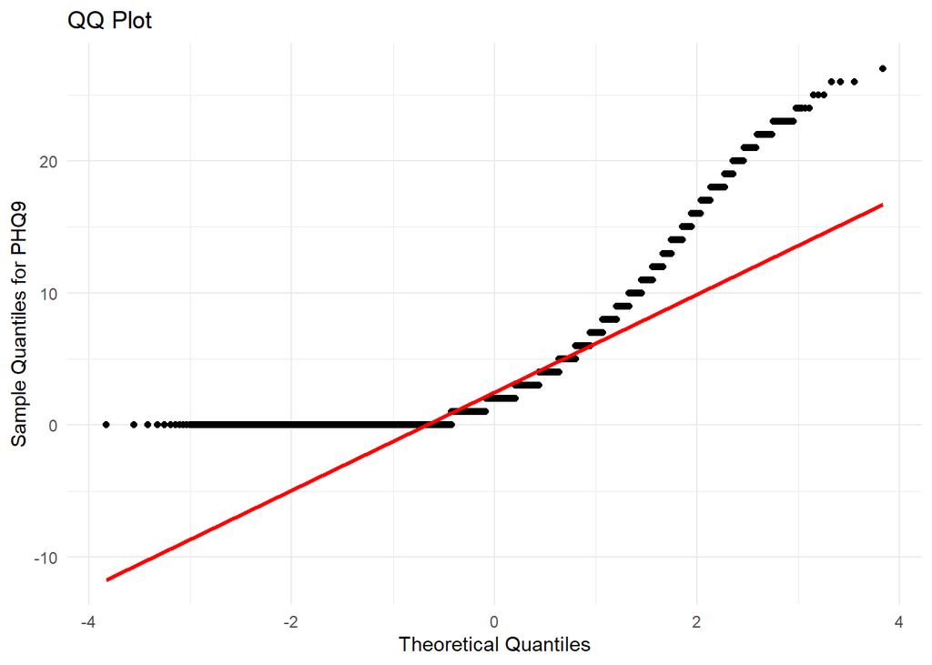

```r
ggplot(nhanes_, aes(sample = PHQ9)) +
  stat_qq() +
  stat_qq_line(color = "red", size = 1) +
  labs(title = "QQ Plot", x = "Theoretical Quantiles", y = "Sample Quantiles for PHQ9") +
  theme_minimal()
```

Try squre root transformation & replot data

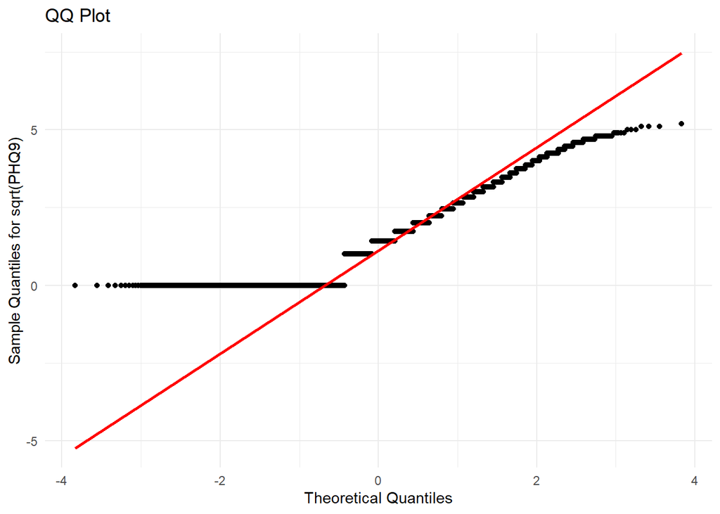

```r
nhanes_ <- nhanes_ %>%
  mutate(PHQ9_sqrt = sqrt(PHQ9))
ggplot(nhanes_, aes(sample = PHQ9_sqrt)) +
  stat_qq() +
  stat_qq_line(color = "red", size = 1) +
  labs(title = "QQ Plot", x = "Theoretical Quantiles", y = "Sample Quantiles for sqrt(PHQ9)") +
  theme_minimal()
```

Try log transformation & replot data (add 1 to handle zero values)

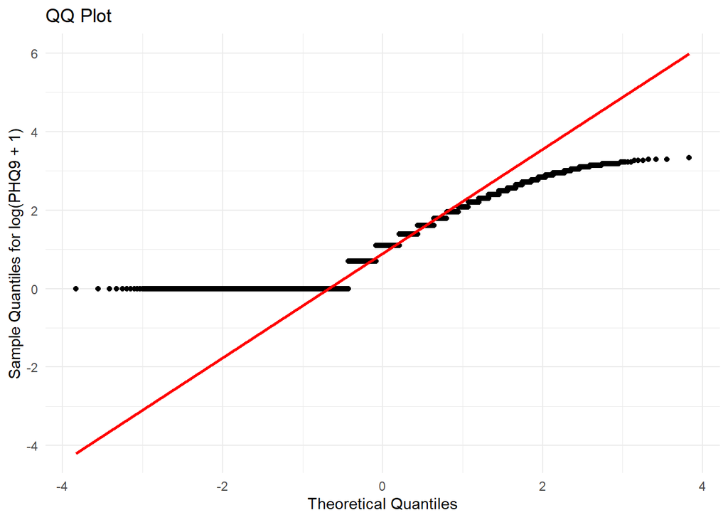

```r
nhanes_ <- nhanes_ %>%
  mutate(PHQ9_log = log(PHQ9 + 1))  # +1 to handle zero values
ggplot(nhanes_, aes(sample = PHQ9_log)) +
  stat_qq() +
  stat_qq_line(color = "red", size = 1) +
  labs(title = "QQ Plot", x = "Theoretical Quantiles", y = "Sample Quantiles for log(PHQ9 + 1)") +
  theme_minimal()
```

Due to poor distribution above, it would be better to treat depression as categorical - a cut-off of 10 was used (https://doi.org/10.1503/cmaj.110829)

```r
nhanes_ <- nhanes_ %>%
  mutate(PHQ9_binary = case_when(
    PHQ9 >= 10 ~ 1,
    PHQ9 < 10 ~ 0,
    TRUE ~ NA_real_
  ))
freq(nhanes_$PHQ9_binary)
```

```
## Frequencies
## nhanes_$PHQ9_binary
## Type: Numeric
##
##               Freq   % Valid   % Valid Cum.   % Total   % Total Cum.
## ----------- ------ --------- -------------- --------- --------------
##           0   7160     90.77          90.77     83.80          83.80
##           1    728      9.23         100.00      8.52          92.32
##        <NA>    656                               7.68         100.00
##       Total   8544    100.00         100.00    100.00         100.00
```

Drop PHQ9 variables not used

```r
nhanes_ <- nhanes_ %>% select(-c(PHQ9_sqrt, PHQ9_log))
```

Export nhanes & nhanes_ for use later if needed (Tableau, etc.)

```r
write.csv(nhanes_, "nhanes_.csv", row.names = FALSE)
write.csv(nhanes, "nhanes_all_variables.csv", row.names = FALSE)
```

Keep only dataframes I want to use moving forward

```r
rm(list = setdiff(ls(), c("nhanes_", "nhanes")))
```

I also want to drop US_time due to high amount of missing data

```r
nhanes_ <- nhanes_ %>% select(-c(US_time))
```

Create train/test split for data

```r
set.seed(123)  # for reproducibility

# 70% training, 30% test
train_index <- sample(nrow(nhanes_), size = 0.7 * nrow(nhanes_))
train_data <- nhanes_[train_index, ]
test_data  <- nhanes_[-train_index, ]
```

Run regression model for Depression (Logit) w/o imputation

```r
depression_mod <- glm(PHQ9_binary ~ Current_drink + gender + as.factor(age_cat) + as.factor(RIDRETH3) + as.factor(educat) + as.factor(PIR_cat) + as.factor(Marriage) + US_born + as.factor(FSDHH) + No_insurance + current_job + sedentary_risk + current_smoke,
             data = train_data,
             family = binomial)
```

Get summary of model w/ coefficients, p-values, and odds ratios w/ 95% CI

```r
summary(depression_mod)           # Coefficients, p-values
```

```
##
## Call:
## glm(formula = PHQ9_binary ~ Current_drink + gender + as.factor(age_cat) +
##     as.factor(RIDRETH3) + as.factor(educat) + as.factor(PIR_cat) +
##     as.factor(Marriage) + US_born + as.factor(FSDHH) + No_insurance +
##     current_job + sedentary_risk + current_smoke, family = binomial,
##     data = train_data)
##
## Coefficients:
##                       Estimate Std. Error z value Pr(>|z|)
## (Intercept)          -2.061387   0.409506  -5.034 4.81e-07 ***
## Current_drink        -0.068177   0.139259  -0.490 0.624440
## gender               -0.453064   0.122258  -3.706 0.000211 ***
## as.factor(age_cat)1  -0.164804   0.227231  -0.725 0.468285
## as.factor(age_cat)2   0.048887   0.223688   0.219 0.826999
## as.factor(age_cat)3   0.122981   0.215561   0.571 0.568328
## as.factor(age_cat)4  -0.072753   0.223630  -0.325 0.744931
## as.factor(age_cat)5  -0.609203   0.257750  -2.364 0.018101 *
## as.factor(RIDRETH3)2  0.102881   0.257688   0.399 0.689711
## as.factor(RIDRETH3)3  0.064046   0.235771   0.272 0.785895
## as.factor(RIDRETH3)4 -0.287050   0.245717  -1.168 0.242720
## as.factor(RIDRETH3)6 -0.023106   0.343819  -0.067 0.946418
## as.factor(RIDRETH3)7  0.815986   0.289708   2.817 0.004854 **
## as.factor(educat)2   -0.045190   0.276594  -0.163 0.870221
## as.factor(educat)3   -0.021290   0.260726  -0.082 0.934920
## as.factor(educat)4   -0.450848   0.268212  -1.681 0.092774 .
## as.factor(educat)5   -0.553298   0.305979  -1.808 0.070561 .
## as.factor(PIR_cat)1   0.204089   0.189336   1.078 0.281069
## as.factor(PIR_cat)2  -0.005151   0.221483  -0.023 0.981447
## as.factor(PIR_cat)3  -0.038035   0.208053  -0.183 0.854942
## as.factor(Marriage)2  0.383312   0.143644   2.668 0.007619 **
## as.factor(Marriage)3  0.316703   0.166436   1.903 0.057060 .
## US_born              -0.335739   0.216249  -1.553 0.120530
## as.factor(FSDHH)2     0.686232   0.175551   3.909 9.27e-05 ***
## as.factor(FSDHH)3     0.917027   0.177038   5.180 2.22e-07 ***
## as.factor(FSDHH)4     1.489628   0.181560   8.205 2.31e-16 ***
## No_insurance         -0.001304   0.167654  -0.008 0.993795
## current_job          -0.778452   0.143973  -5.407 6.41e-08 ***
## sedentary_risk        0.366100   0.126334   2.898 0.003757 **
## current_smoke         0.180209   0.141307   1.275 0.202202
## ---
## Signif. codes:  0 '***' 0.001 '**' 0.01 '*' 0.05 '.' 0.1 ' ' 1
##
## (Dispersion parameter for binomial family taken to be 1)
##
##     Null deviance: 2383.7  on 3721  degrees of freedom
## Residual deviance: 2088.4  on 3692  degrees of freedom
##   (2258 observations deleted due to missingness)
## AIC: 2148.4
##
## Number of Fisher Scoring iterations: 6
```

```r
#exp(coef(depression_mod))         # Odds ratios
#exp(confint(depression_mod))      # Confidence intervals for odds ratios
```

Test model for multicollinearity - no values above 5

```r
library(car)
vif(depression_mod)
```

```
##                         GVIF Df GVIF^(1/(2*Df))
## Current_drink       1.162704  1        1.078288
## gender              1.072695  1        1.035710
## as.factor(age_cat)  1.931243  5        1.068031
## as.factor(RIDRETH3) 2.532801  5        1.097388
## as.factor(educat)   1.707960  4        1.069202
## as.factor(PIR_cat)  1.838678  3        1.106839
## as.factor(Marriage) 1.431292  2        1.093785
## US_born             2.092741  1        1.446631
## as.factor(FSDHH)    1.534329  3        1.073956
## No_insurance        1.146150  1        1.070584
## current_job         1.415215  1        1.189628
## sedentary_risk      1.065732  1        1.032343
## current_smoke       1.206638  1        1.098471
```

Generate predicted probabilities on the test data & roc_obj along w/ AUC

```r
library(pROC)
test_data$predicted_prob <- predict(depression_mod, newdata = test_data, type = "response")
roc_obj <- roc(test_data$PHQ9_binary, test_data$predicted_prob)
auc(roc_obj)
```

```
## Area under the curve: 0.7164
```

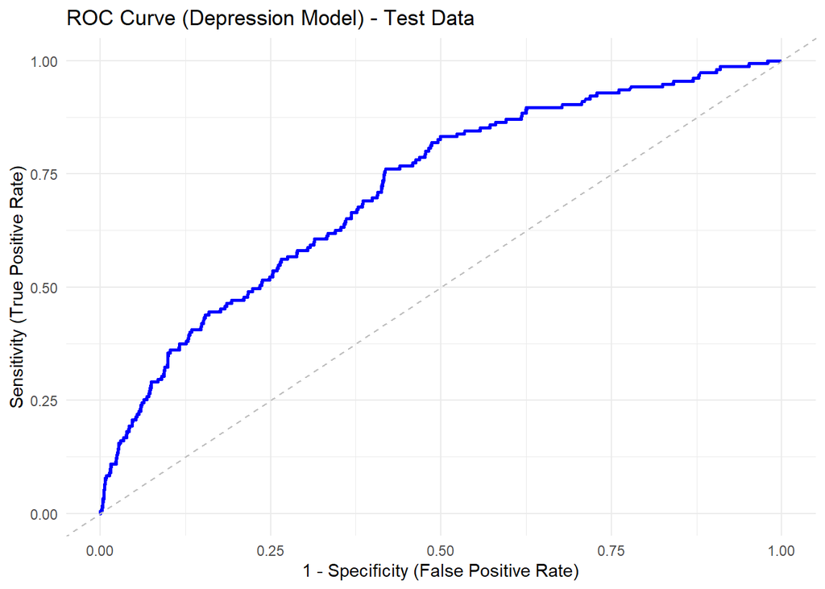

```r
roc_df <- data.frame(
  specificity = roc_obj$specificities,
  sensitivity = roc_obj$sensitivities,
  fpr = 1 - roc_obj$specificities
)

# Plot
ggplot(roc_df, aes(x = fpr, y = sensitivity)) +
  geom_line(color = "blue", size = 1) +
  geom_abline(slope = 1, intercept = 0, linetype = "dashed", color = "gray") +
  labs(title = "ROC Curve (Depression Model) - Test Data",
       x = "1 - Specificity (False Positive Rate)",
       y = "Sensitivity (True Positive Rate)") +
  xlim(0, 1) +
  ylim(0, 1) +
  theme_minimal()
```

Run regression model for Depression (Logit) w/o imputation using LASSO regularization

```r
library(glmnet)
model_vars <- c("PHQ9_binary", "Current_drink", "gender", "age_cat", "RIDRETH3",
                "educat", "PIR_cat", "Marriage", "US_born", "FSDHH", "No_insurance",
                "current_job", "sedentary_risk", "current_smoke")

train_complete <- train_data %>%
  select(all_of(model_vars)) %>%
  drop_na()

lasso_formula <- PHQ9_binary ~ Current_drink + gender + as.factor(age_cat) +
                  as.factor(RIDRETH3) + as.factor(educat) +
                  as.factor(PIR_cat) + as.factor(Marriage) +
                  US_born + as.factor(FSDHH) +
                  No_insurance + current_job + sedentary_risk +
                  current_smoke

# Create predictor matrix (excluding the outcome), automatically handles factors
x_train <- model.matrix(lasso_formula, data = train_complete)[, -1]
train_cols <- colnames(x_train)


# Create outcome vector
y <- train_complete$PHQ9_binary
```

Below code is applying k-fold cross-validation (with default of 10-folds) within training data to find the best λ (penalty strength) that minimizes error

```r
set.seed(123)
cv_lasso <- cv.glmnet(x_train, y, alpha = 1, family = "binomial", type.measure = "class")
```

Identify variables selected from LASSO regularization

```r
# Extract coefficients as sparse matrix
lasso_coef <- coef(cv_lasso, s = cv_lasso$lambda.min)

# Convert to a tidy tibble (rename properly)
library(tibble)

lasso_vars <- as_tibble(as.matrix(lasso_coef), rownames = "Variable") %>%
  rename(Coefficient = `s1`) %>%  # 's1' is often the auto-assigned column name
  filter(Coefficient != 0)


# View selected variables
print(lasso_vars)
```

```
## # A tibble: 19 × 2
##    Variable             Coefficient
##    <chr>                      <dbl>
##  1 (Intercept)              -2.28
##  2 gender                   -0.317
##  3 as.factor(age_cat)3       0.0303
##  4 as.factor(age_cat)5      -0.287
##  5 as.factor(RIDRETH3)4     -0.0758
##  6 as.factor(RIDRETH3)7      0.680
##  7 as.factor(educat)2        0.0528
##  8 as.factor(educat)3        0.151
##  9 as.factor(educat)4       -0.0768
## 10 as.factor(educat)5       -0.214
## 11 as.factor(Marriage)2      0.216
## 12 as.factor(Marriage)3      0.0901
## 13 US_born                  -0.0999
## 14 as.factor(FSDHH)2         0.454
## 15 as.factor(FSDHH)3         0.708
## 16 as.factor(FSDHH)4         1.34
## 17 current_job              -0.634
## 18 sedentary_risk            0.215
## 19 current_smoke             0.170
```

Get complete data for test data

```r
# Drop NAs in all relevant variables
test_complete <- test_data %>%
  select(all.vars(lasso_formula)) %>%
  drop_na()

# Create model matrix for test set
x_test <- model.matrix(lasso_formula, data = test_complete)[, -1]

# Add any missing columns with 0s
missing_cols <- setdiff(train_cols, colnames(x_test))
for (col in missing_cols) {
  x_test <- cbind(x_test, setNames(data.frame(0), col))
}

# Reorder columns to match training
x_test <- x_test[, train_cols]
y_test <- test_complete$PHQ9_binary
```

Compare AUC for LASSO compared to original full model

```r
library(pROC)

# generate predicted prob for LASSO model
lasso_pred_prob <- predict(cv_lasso, newx = x_test, s = cv_lasso$lambda.min, type = "response")

# AUC for LASSO
lasso_roc <- roc(y_test, as.vector(lasso_pred_prob))
lasso_auc <- auc(lasso_roc)

# AUC for standard GLM
glm_roc <- roc(test_data$PHQ9_binary, test_data$predicted_prob)
glm_auc <- auc(glm_roc)

# Print both
cat("LASSO AUC:", lasso_auc, "\n")
```

```
## LASSO AUC: 0.7180207
```

```r
cat("GLM AUC:", glm_auc, "\n")
```

```
## GLM AUC: 0.7164101
```

Plot ROC Curve for both models (base R)

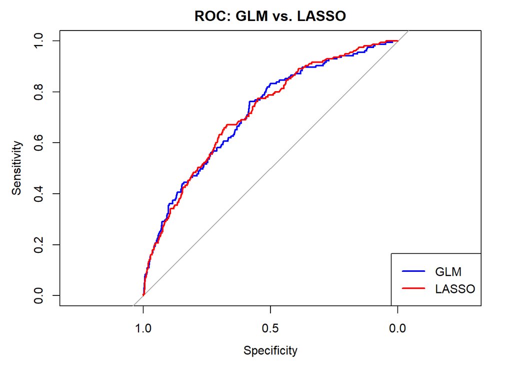

```r
plot(glm_roc,
     col = "blue",
     main = "ROC: GLM vs. LASSO")  # Flips x-axis to 0 → 1

# Add LASSO ROC curve
lines(lasso_roc, col = "red")

# Add legend
legend("bottomright",
       legend = c("GLM", "LASSO"),
       col = c("blue", "red"),
       lwd = 2)
```

Plot ROC Curves for both models (better curve)

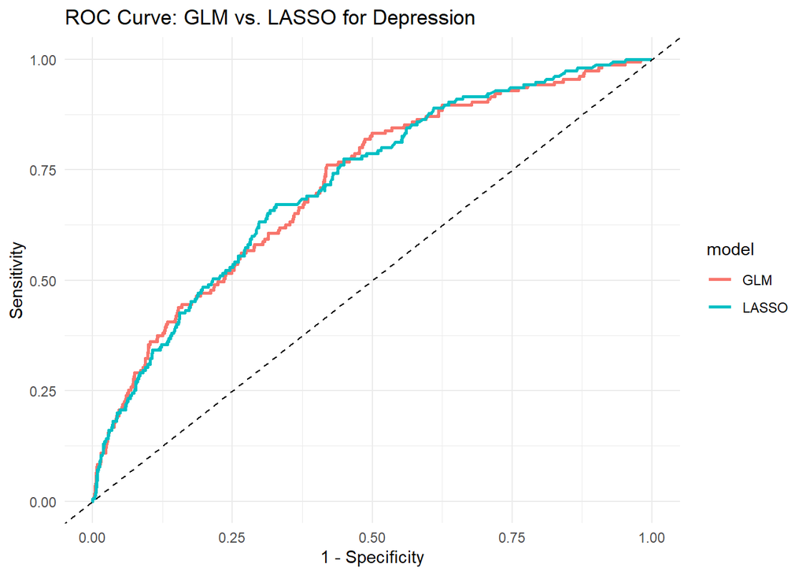

```r
# Create data frames from both ROC objects
glm_df <- data.frame(
  fpr = 1 - glm_roc$specificities,
  tpr = glm_roc$sensitivities,
  model = "GLM"
)

lasso_df <- data.frame(
  fpr = 1 - lasso_roc$specificities,
  tpr = lasso_roc$sensitivities,
  model = "LASSO"
)

# Combine for plotting
roc_df <- rbind(glm_df, lasso_df)

# Plot ROC curves with ggplot2
ggplot(roc_df, aes(x = fpr, y = tpr, color = model)) +
  geom_line(size = 1) +
  geom_abline(slope = 1, intercept = 0, linetype = "dashed") +
  scale_x_continuous(name = "1 - Specificity", limits = c(0, 1)) +
  scale_y_continuous(name = "Sensitivity", limits = c(0, 1)) +
  labs(title = "ROC Curve: GLM vs. LASSO for Depression") +
  theme_minimal()
```

Repeat process above for diabetes instead of depression

```r
diabetes_mod <- glm(diabetes ~ Current_drink + gender + as.factor(age_cat) + as.factor(RIDRETH3) + as.factor(educat) + as.factor(PIR_cat) + as.factor(Marriage) + US_born + as.factor(FSDHH) + No_insurance + current_job + sedentary_risk + current_smoke,
             data = train_data,
             family = binomial)
```

Get summary of diabetes model above - this model seems to have better predictors from p-values

```r
summary(diabetes_mod)           # Coefficients, p-values
```

```
##
## Call:
## glm(formula = diabetes ~ Current_drink + gender + as.factor(age_cat) +
##     as.factor(RIDRETH3) + as.factor(educat) + as.factor(PIR_cat) +
##     as.factor(Marriage) + US_born + as.factor(FSDHH) + No_insurance +
##     current_job + sedentary_risk + current_smoke, family = binomial,
##     data = train_data)
##
## Coefficients:
##                       Estimate Std. Error z value Pr(>|z|)
## (Intercept)          -3.211527   0.429957  -7.469 8.06e-14 ***
## Current_drink        -0.270571   0.100374  -2.696 0.007026 **
## gender                0.375834   0.093369   4.025 5.69e-05 ***
## as.factor(age_cat)1   0.936506   0.380946   2.458 0.013957 *
## as.factor(age_cat)2   2.106354   0.349158   6.033 1.61e-09 ***
## as.factor(age_cat)3   2.490805   0.342138   7.280 3.34e-13 ***
## as.factor(age_cat)4   3.159789   0.341034   9.265  < 2e-16 ***
## as.factor(age_cat)5   3.007051   0.352611   8.528  < 2e-16 ***
## as.factor(RIDRETH3)2 -0.498698   0.198906  -2.507 0.012169 *
## as.factor(RIDRETH3)3 -0.625699   0.183128  -3.417 0.000634 ***
## as.factor(RIDRETH3)4 -0.348844   0.186114  -1.874 0.060882 .
## as.factor(RIDRETH3)6  0.111125   0.217444   0.511 0.609316
## as.factor(RIDRETH3)7 -0.244901   0.263474  -0.930 0.352627
## as.factor(educat)2   -0.145408   0.217211  -0.669 0.503220
## as.factor(educat)3   -0.184230   0.202643  -0.909 0.363278
## as.factor(educat)4   -0.131372   0.203856  -0.644 0.519291
## as.factor(educat)5   -0.412205   0.220437  -1.870 0.061492 .
## as.factor(PIR_cat)1   0.049168   0.128606   0.382 0.702227
## as.factor(PIR_cat)2   0.004936   0.158256   0.031 0.975116
## as.factor(PIR_cat)3   0.084072   0.154817   0.543 0.587099
## as.factor(Marriage)2 -0.193528   0.108904  -1.777 0.075559 .
## as.factor(Marriage)3 -0.166092   0.162373  -1.023 0.306354
## US_born              -0.072612   0.161553  -0.449 0.653099
## as.factor(FSDHH)2     0.275628   0.139882   1.970 0.048789 *
## as.factor(FSDHH)3     0.409693   0.150171   2.728 0.006369 **
## as.factor(FSDHH)4     0.279165   0.175523   1.590 0.111727
## No_insurance         -0.270050   0.162004  -1.667 0.095527 .
## current_job          -0.440366   0.117595  -3.745 0.000181 ***
## sedentary_risk        0.463363   0.097141   4.770 1.84e-06 ***
## current_smoke        -0.286227   0.128750  -2.223 0.026207 *
## ---
## Signif. codes:  0 '***' 0.001 '**' 0.01 '*' 0.05 '.' 0.1 ' ' 1
##
## (Dispersion parameter for binomial family taken to be 1)
##
##     Null deviance: 3704.7  on 3754  degrees of freedom
## Residual deviance: 3131.8  on 3725  degrees of freedom
##   (2225 observations deleted due to missingness)
## AIC: 3191.8
##
## Number of Fisher Scoring iterations: 6
```

```r
#exp(coef(diabetes_mod))         # Odds ratios
#exp(confint(diabetes_mod))      # Confidence intervals for odds ratios
```

Test for multicollinearity in model - no values 5 or greater

```r
vif(diabetes_mod)
```

```
##                         GVIF Df GVIF^(1/(2*Df))
## Current_drink       1.117272  1        1.057011
## gender              1.081223  1        1.039819
## as.factor(age_cat)  1.857751  5        1.063895
## as.factor(RIDRETH3) 3.303667  5        1.126937
## as.factor(educat)   1.788781  4        1.075399
## as.factor(PIR_cat)  1.977340  3        1.120332
## as.factor(Marriage) 1.324578  2        1.072802
## US_born             2.495706  1        1.579781
## as.factor(FSDHH)    1.609608  3        1.082563
## No_insurance        1.126036  1        1.061148
## current_job         1.618678  1        1.272273
## sedentary_risk      1.071712  1        1.035235
## current_smoke       1.165044  1        1.079372
```

Generate predicted probabilities on test data

```r
test_data$predicted_prob_b <- predict(diabetes_mod, newdata = test_data, type = "response")
roc_obj_b <- roc(test_data$diabetes, test_data$predicted_prob_b)
auc(roc_obj_b)
```

```
## Area under the curve: 0.7435
```

Generate ROC Curve - a little better predictive accuracy than depression

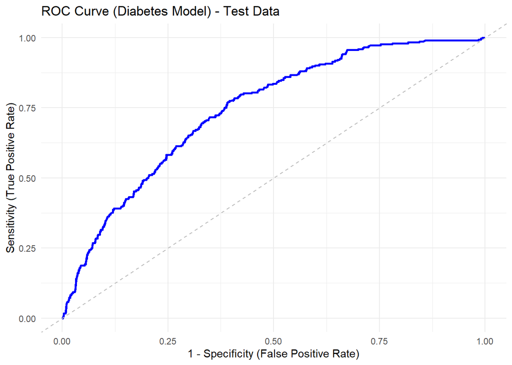

```r
roc_df_b <- data.frame(
  specificity = roc_obj_b$specificities,
  sensitivity = roc_obj_b$sensitivities,
  fpr = 1 - roc_obj_b$specificities
)

# Plot
ggplot(roc_df_b, aes(x = fpr, y = sensitivity)) +
  geom_line(color = "blue", size = 1) +
  geom_abline(slope = 1, intercept = 0, linetype = "dashed", color = "gray") +
  labs(title = "ROC Curve (Diabetes Model) - Test Data",
       x = "1 - Specificity (False Positive Rate)",
       y = "Sensitivity (True Positive Rate)") +
  xlim(0, 1) +
  ylim(0, 1) +
  theme_minimal()
```

Create LASSO model for diabetes

```r
model_vars_b <- c("diabetes", "Current_drink", "gender", "age_cat", "RIDRETH3",
                "educat", "PIR_cat", "Marriage", "US_born", "FSDHH", "No_insurance",
                "current_job", "sedentary_risk", "current_smoke")

train_complete_b <- train_data %>%
  select(all_of(model_vars_b)) %>%
  drop_na()

lasso_formula_b <- diabetes ~ Current_drink + gender + as.factor(age_cat) +
                  as.factor(RIDRETH3) + as.factor(educat) +
                  as.factor(PIR_cat) + as.factor(Marriage) +
                  US_born + as.factor(FSDHH) +
                  No_insurance + current_job + sedentary_risk +
                  current_smoke

# Create predictor matrix (excluding the outcome), automatically handles factors
x_train_b <- model.matrix(lasso_formula_b, data = train_complete_b)[, -1]
train_cols_b <- colnames(x_train_b)


# Create outcome vector
y_b <- train_complete_b$diabetes
```

Below code is applying k-fold cross-validation (with default of 10-folds) within training data to find the best λ (penalty strength) that minimizes error

```r
set.seed(123)
cv_lasso_b <- cv.glmnet(x_train_b, y_b, alpha = 1, family = "binomial", type.measure = "class")
```

Identify variables selected from LASSO regularization

```r
# Extract coefficients as sparse matrix
lasso_coef_b <- coef(cv_lasso_b, s = cv_lasso_b$lambda.min)

# Convert to a tidy tibble (rename properly)
library(tibble)

lasso_vars_b <- as_tibble(as.matrix(lasso_coef_b), rownames = "Variable") %>%
  rename(Coefficient = `s1`) %>%  # 's1' is often the auto-assigned column name
  filter(Coefficient != 0)


# View selected variables
print(lasso_vars_b)
```

```
## # A tibble: 26 × 2
##    Variable             Coefficient
##    <chr>                      <dbl>
##  1 (Intercept)              -2.61
##  2 Current_drink            -0.289
##  3 gender                    0.354
##  4 as.factor(age_cat)1       0.0311
##  5 as.factor(age_cat)2       1.25
##  6 as.factor(age_cat)3       1.63
##  7 as.factor(age_cat)4       2.31
##  8 as.factor(age_cat)5       2.14
##  9 as.factor(RIDRETH3)2     -0.332
## 10 as.factor(RIDRETH3)3     -0.453
## # ℹ 16 more rows
```

Get complete data for test data

```r
# Drop NAs in all relevant variables
test_complete_b <- test_data %>%
  select(all.vars(lasso_formula_b)) %>%
  drop_na()

# Create model matrix for test set
x_test_b <- model.matrix(lasso_formula_b, data = test_complete_b)[, -1]

# Add any missing columns with 0s
missing_cols_b <- setdiff(train_cols_b, colnames(x_test_b))
for (col in missing_cols_b) {
  x_test_b <- cbind(x_test_b, setNames(data.frame(0), col))
}

# Reorder columns to match training
x_test_b <- x_test_b[, train_cols_b]
y_test_b <- test_complete_b$diabetes
```

Compare AUC for LASSO compared to original full model - not a huge difference in LASSO vs full model

```r
# generate predicted prob for LASSO model
lasso_pred_prob_b <- predict(cv_lasso_b, newx = x_test_b, s = cv_lasso_b$lambda.min, type = "response")

# AUC for LASSO
lasso_roc_b <- roc(y_test_b, as.vector(lasso_pred_prob_b))
lasso_auc_b <- auc(lasso_roc_b)

# AUC for standard GLM
glm_roc_b <- roc(test_data$diabetes, test_data$predicted_prob_b)
glm_auc_b <- auc(glm_roc_b)

# Print both
cat("LASSO AUC:", lasso_auc_b, "\n")
```

```
## LASSO AUC: 0.7421238
```

```r
cat("GLM AUC:", glm_auc_b, "\n")
```

```
## GLM AUC: 0.7434786
```

Compare ROC curves for LASS vs GLM full model

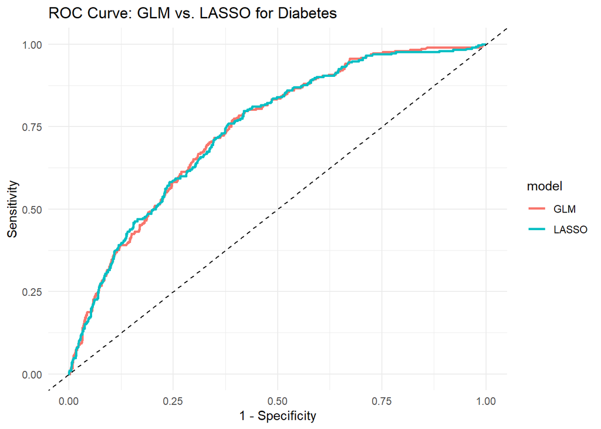

```r
# Create data frames from both ROC objects
glm_df_b <- data.frame(
  fpr = 1 - glm_roc_b$specificities,
  tpr = glm_roc_b$sensitivities,
  model = "GLM"
)

lasso_df_b <- data.frame(
  fpr = 1 - lasso_roc_b$specificities,
  tpr = lasso_roc_b$sensitivities,
  model = "LASSO"
)

# Combine for plotting
roc_df_b <- rbind(glm_df_b, lasso_df_b)

# Plot ROC curves with ggplot2
ggplot(roc_df_b, aes(x = fpr, y = tpr, color = model)) +
  geom_line(size = 1) +
  geom_abline(slope = 1, intercept = 0, linetype = "dashed") +
  scale_x_continuous(name = "1 - Specificity", limits = c(0, 1)) +
  scale_y_continuous(name = "Sensitivity", limits = c(0, 1)) +
  labs(title = "ROC Curve: GLM vs. LASSO for Diabetes") +
  theme_minimal()
```

Run regression model for models above with multiple imputation for diabetes

```r
library(mice)

model_vars_b <- c("diabetes", "Current_drink", "gender", "age_cat", "RIDRETH3",
                  "educat", "PIR_cat", "Marriage", "US_born", "FSDHH",
                  "No_insurance", "current_job", "sedentary_risk", "current_smoke")

# Subset and run mice
impute_data <- train_data %>%
  select(all_of(model_vars_b))

#m=5 is specifying we are creating 5 imputed datasets - methd = pmm is stating to use Predictive Mean Matching for imputation (default)
imp_b <- mice(impute_data, m = 5, method = "pmm", seed = 2024)
```

Run GLM on imputed data

```r
diabetes_mod_imp <- with(imp_b, glm(diabetes ~ Current_drink + gender + as.factor(age_cat) +
                                  as.factor(RIDRETH3) + as.factor(educat) + as.factor(PIR_cat) +
                                  as.factor(Marriage) + US_born + as.factor(FSDHH) +
                                  No_insurance + current_job + sedentary_risk + current_smoke,
                                family = binomial))
options(scipen = 999)
# Pool results across imputations
pooled_diabetes_mod <- pool(diabetes_mod_imp)
summary(pooled_diabetes_mod)
```

```
##                    term    estimate  std.error  statistic        df
## 1           (Intercept) -3.35349441 0.34197600 -9.8062273  869.1113
## 2         Current_drink -0.37375942 0.08715961 -4.2882184  125.9144
## 3                gender  0.35669058 0.07481155  4.7678547 5832.4559
## 4   as.factor(age_cat)1  0.88632899 0.29486583  3.0058722 4980.9415
## 5   as.factor(age_cat)2  1.91793217 0.27171343  7.0586580 4595.6472
## 6   as.factor(age_cat)3  2.56201276 0.26465145  9.6807054 4239.7757
## 7   as.factor(age_cat)4  3.02942686 0.26562748 11.4047946 4213.0241
## 8   as.factor(age_cat)5  2.99345467 0.27553111 10.8643074 4142.9201
## 9  as.factor(RIDRETH3)2 -0.43227793 0.15704120 -2.7526403 5017.2527
## 10 as.factor(RIDRETH3)3 -0.58326136 0.14904682 -3.9132762 5304.9027
## 11 as.factor(RIDRETH3)4 -0.21444039 0.14726854 -1.4561182 5491.4095
## 12 as.factor(RIDRETH3)6 -0.04047516 0.16027813 -0.2525307 5646.6812
## 13 as.factor(RIDRETH3)7 -0.02508896 0.20482121 -0.1224920 5886.4391
## 14   as.factor(educat)2 -0.08098498 0.15823480 -0.5118026 5292.1053
```

[output cut: 47 more lines]

Generate OR & 95% CI

```r
library(dplyr)

# Extract summary and ensure it's a proper data frame
mod_df <- as.data.frame(summary(pooled_diabetes_mod))

# Add ORs, 95% CIs, and round everything to 4 decimals
mod_df <- mod_df %>%
  mutate(
    OR = round(exp(estimate), 4),
    lower_CI = round(exp(estimate - 1.96 * std.error), 4),
    upper_CI = round(exp(estimate + 1.96 * std.error), 4),
    estimate = round(estimate, 4),
    std.error = round(std.error, 4),
    p.value = round(p.value, 4)
  )

mod_df_sig <- mod_df %>%
  filter(p.value < 0.05)

# View the result
print(mod_df_sig)
```

```
##                    term estimate std.error statistic        df p.value      OR
## 1           (Intercept)  -3.3535    0.3420 -9.806227  869.1113  0.0000  0.0350
## 2         Current_drink  -0.3738    0.0872 -4.288218  125.9144  0.0000  0.6881
## 3                gender   0.3567    0.0748  4.767855 5832.4559  0.0000  1.4286
## 4   as.factor(age_cat)1   0.8863    0.2949  3.005872 4980.9415  0.0027  2.4262
## 5   as.factor(age_cat)2   1.9179    0.2717  7.058658 4595.6472  0.0000  6.8069
## 6   as.factor(age_cat)3   2.5620    0.2647  9.680705 4239.7757  0.0000 12.9619
## 7   as.factor(age_cat)4   3.0294    0.2656 11.404795 4213.0241  0.0000 20.6854
## 8   as.factor(age_cat)5   2.9935    0.2755 10.864307 4142.9201  0.0000 19.9545
## 9  as.factor(RIDRETH3)2  -0.4323    0.1570 -2.752640 5017.2527  0.0059  0.6490
## 10 as.factor(RIDRETH3)3  -0.5833    0.1490 -3.913276 5304.9027  0.0001  0.5581
## 11 as.factor(Marriage)2  -0.1830    0.0877 -2.086044 5897.9478  0.0370  0.8328
## 12    as.factor(FSDHH)3   0.3707    0.1200  3.089763 1020.7224  0.0021  1.4488
## 13    as.factor(FSDHH)4   0.3820    0.1390  2.747949 4504.7627  0.0060  1.4652
## 14         No_insurance  -0.2403    0.1207 -1.991471 5449.2574  0.0465  0.7864
```

[output cut: 19 more lines]

```r
# View clean output
print(mod_df)
```

```
##                    term estimate std.error  statistic        df p.value      OR
## 1           (Intercept)  -3.3535    0.3420 -9.8062273  869.1113  0.0000  0.0350
## 2         Current_drink  -0.3738    0.0872 -4.2882184  125.9144  0.0000  0.6881
## 3                gender   0.3567    0.0748  4.7678547 5832.4559  0.0000  1.4286
## 4   as.factor(age_cat)1   0.8863    0.2949  3.0058722 4980.9415  0.0027  2.4262
## 5   as.factor(age_cat)2   1.9179    0.2717  7.0586580 4595.6472  0.0000  6.8069
## 6   as.factor(age_cat)3   2.5620    0.2647  9.6807054 4239.7757  0.0000 12.9619
## 7   as.factor(age_cat)4   3.0294    0.2656 11.4047946 4213.0241  0.0000 20.6854
## 8   as.factor(age_cat)5   2.9935    0.2755 10.8643074 4142.9201  0.0000 19.9545
## 9  as.factor(RIDRETH3)2  -0.4323    0.1570 -2.7526403 5017.2527  0.0059  0.6490
## 10 as.factor(RIDRETH3)3  -0.5833    0.1490 -3.9132762 5304.9027  0.0001  0.5581
## 11 as.factor(RIDRETH3)4  -0.2144    0.1473 -1.4561182 5491.4095  0.1454  0.8070
## 12 as.factor(RIDRETH3)6  -0.0405    0.1603 -0.2525307 5646.6812  0.8006  0.9603
## 13 as.factor(RIDRETH3)7  -0.0251    0.2048 -0.1224920 5886.4391  0.9025  0.9752
## 14   as.factor(educat)2  -0.0810    0.1582 -0.5118026 5292.1053  0.6088  0.9222
```

[output cut: 47 more lines]

Significant Predictors from Pooled Logistic Regression

| Variable | Estimate | Std. Error | OR | 95% CI (Lower) | 95% CI (Upper) | P-Value |
| --- | --- | --- | --- | --- | --- | --- |
| (Intercept) | -3.3535 | 0.3420 | 0.0350 | 0.0179 | 0.0683 | 0.0000 |
| Current_drink | -0.3738 | 0.0872 | 0.6881 | 0.5801 | 0.8163 | 0.0000 |
| gender | 0.3567 | 0.0748 | 1.4286 | 1.2338 | 1.6542 | 0.0000 |
| as.factor(age_cat)1 | 0.8863 | 0.2949 | 2.4262 | 1.3612 | 4.3244 | 0.0027 |
| as.factor(age_cat)2 | 1.9179 | 0.2717 | 6.8069 | 3.9963 | 11.5940 | 0.0000 |
| as.factor(age_cat)3 | 2.5620 | 0.2647 | 12.9619 | 7.7160 | 21.7743 | 0.0000 |
| as.factor(age_cat)4 | 3.0294 | 0.2656 | 20.6854 | 12.2901 | 34.8153 | 0.0000 |
| as.factor(age_cat)5 | 2.9935 | 0.2755 | 19.9545 | 11.6280 | 34.2435 | 0.0000 |
| as.factor(RIDRETH3)2 | -0.4323 | 0.1570 | 0.6490 | 0.4771 | 0.8830 | 0.0059 |
| as.factor(RIDRETH3)3 | -0.5833 | 0.1490 | 0.5581 | 0.4167 | 0.7474 | 0.0001 |
| as.factor(Marriage)2 | -0.1830 | 0.0877 | 0.8328 | 0.7013 | 0.9890 | 0.0370 |
| as.factor(FSDHH)3 | 0.3707 | 0.1200 | 1.4488 | 1.1452 | 1.8329 | 0.0021 |
| as.factor(FSDHH)4 | 0.3820 | 0.1390 | 1.4652 | 1.1158 | 1.9242 | 0.0060 |
| No_insurance | -0.2403 | 0.1207 | 0.7864 | 0.6208 | 0.9962 | 0.0465 |
| current_job | -0.2941 | 0.1031 | 0.7452 | 0.6088 | 0.9122 | 0.0052 |
| sedentary_risk | 0.4887 | 0.0801 | 1.6302 | 1.3934 | 1.9071 | 0.0000 |

Generate ROC/AUC curve

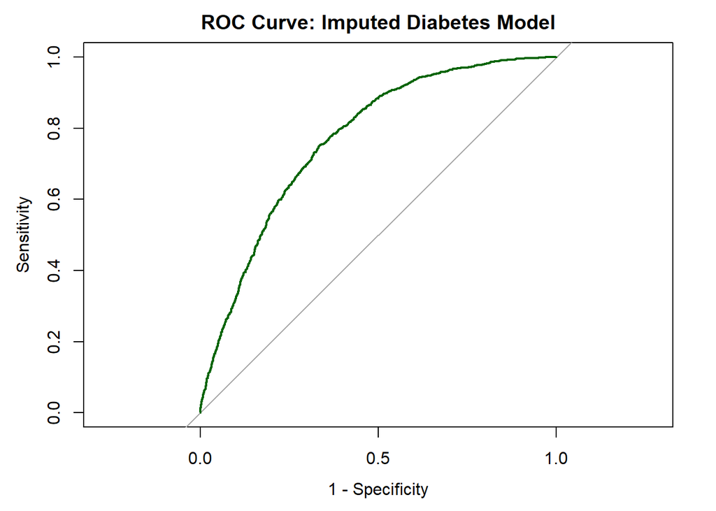

```r
# Extract 1 completed dataset from imputation
comp_diab <- complete(imp_b, 1)

# Step 2: Refit logistic model on completed dataset
glm_diab <- glm(diabetes ~ Current_drink + gender + as.factor(age_cat) +
                  as.factor(RIDRETH3) + as.factor(educat) + as.factor(PIR_cat) +
                  as.factor(Marriage) + US_born + as.factor(FSDHH) +
                  No_insurance + current_job + sedentary_risk + current_smoke,
                data = comp_diab, family = binomial)

# Step 3: Predict probabilities
diab_pred <- predict(glm_diab, type = "response")

# Step 4: Compute ROC and AUC
roc_obj_diab_imp <- roc(comp_diab$diabetes, diab_pred)

# Step 5: Plot ROC curve
plot(roc_obj_diab_imp, legacy.axes = TRUE, col = "darkgreen", main = "ROC Curve: Imputed Diabetes Model")
```

```r
# Step 6: Print AUC
auc(roc_obj_diab_imp)
```

```
## Area under the curve: 0.7693
```

Repeat process of imputation with depression model

```r
# Select variables for imputation
model_vars_dep <- c("PHQ9_binary", "Current_drink", "gender", "age_cat", "RIDRETH3",
                    "educat", "PIR_cat", "Marriage", "US_born", "FSDHH",
                    "No_insurance", "current_job", "sedentary_risk", "current_smoke")

# Subset data and run multiple imputation
impute_data_dep <- train_data %>%
  select(all_of(model_vars_dep))

imp_dep <- mice(impute_data_dep, m = 5, method = "pmm", seed = 2024)
```

Fit logistic regression model & pool results

```r
# Fit logistic regression model on imputed datasets
depression_mod_imp <- with(imp_dep, glm(PHQ9_binary ~ Current_drink + gender +
                                        as.factor(age_cat) + as.factor(RIDRETH3) +
                                        as.factor(educat) + as.factor(PIR_cat) +
                                        as.factor(Marriage) + US_born +
                                        as.factor(FSDHH) + No_insurance +
                                        current_job + sedentary_risk + current_smoke,
                                        family = binomial))

# Pool results
pooled_depression_mod <- pool(depression_mod_imp)
```

Summarize results

```r
# Format output with ORs and 95% CI
dep_df <- as.data.frame(summary(pooled_depression_mod))

# Calculate odds ratios and CIs
dep_df <- dep_df %>%
  mutate(
    OR        = round(exp(estimate), 4),
    lower_CI  = round(exp(estimate - 1.96 * std.error), 4),
    upper_CI  = round(exp(estimate + 1.96 * std.error), 4),
    estimate  = round(estimate, 4),
    std.error = round(std.error, 4),
    p.value   = round(p.value, 4)
  )

# Filter for statistically significant predictors
dep_df_sig <- dep_df %>%
  filter(p.value < 0.05)
```

Aesthetically pleasing printout

```r
dep_df_sig %>%
  select(term, OR, lower_CI, upper_CI, std.error, p.value) %>%
  kable(digits = 4, caption = "Significant Predictors from Pooled Depression Model",
        col.names = c("Variable", "OR", "95% CI (Lower)", "95% CI (Upper)", "Std. Error", "P-Value")) %>%
  kable_styling(bootstrap_options = c("striped", "hover", "condensed"), full_width = FALSE)
```

Significant Predictors from Pooled Depression Model

| Variable | OR | 95% CI (Lower) | 95% CI (Upper) | Std. Error | P-Value |
| --- | --- | --- | --- | --- | --- |
| (Intercept) | 0.1599 | 0.0810 | 0.3156 | 0.3469 | 0.0000 |
| gender | 0.6643 | 0.5416 | 0.8146 | 0.1041 | 0.0001 |
| as.factor(age_cat)5 | 0.6010 | 0.3891 | 0.9285 | 0.2219 | 0.0227 |
| as.factor(RIDRETH3)7 | 1.7203 | 1.0740 | 2.7555 | 0.2404 | 0.0243 |
| as.factor(educat)4 | 0.5837 | 0.3662 | 0.9305 | 0.2379 | 0.0320 |
| as.factor(educat)5 | 0.4868 | 0.2872 | 0.8250 | 0.2691 | 0.0113 |
| as.factor(Marriage)2 | 1.5203 | 1.2015 | 1.9237 | 0.1201 | 0.0005 |
| US_born | 0.6666 | 0.4691 | 0.9472 | 0.1792 | 0.0249 |
| as.factor(FSDHH)2 | 1.8414 | 1.3572 | 2.4984 | 0.1557 | 0.0001 |
| as.factor(FSDHH)3 | 2.1717 | 1.5824 | 2.9805 | 0.1615 | 0.0000 |
| as.factor(FSDHH)4 | 3.9547 | 2.7339 | 5.7206 | 0.1884 | 0.0000 |
| current_job | 0.4266 | 0.3134 | 0.5807 | 0.1574 | 0.0000 |
| sedentary_risk | 1.3515 | 1.0801 | 1.6910 | 0.1143 | 0.0094 |
| current_smoke | 1.4083 | 1.0989 | 1.8049 | 0.1266 | 0.0078 |

ROC Curve

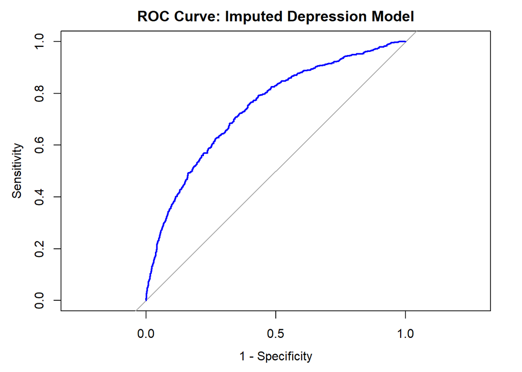

```r
# Use one completed dataset for evaluation
comp_dep <- complete(imp_dep, 1)

# Refit model on this for predictions
glm_dep <- glm(PHQ9_binary ~ Current_drink + gender + as.factor(age_cat) +
                  as.factor(RIDRETH3) + as.factor(educat) + as.factor(PIR_cat) +
                  as.factor(Marriage) + US_born + as.factor(FSDHH) +
                  No_insurance + current_job + sedentary_risk + current_smoke,
                data = comp_dep, family = binomial)

# Predict probabilities
dep_pred <- predict(glm_dep, type = "response")

# ROC and AUC
roc_obj_dep_imp <- roc(comp_dep$PHQ9_binary, dep_pred)
plot(roc_obj_dep_imp, legacy.axes = TRUE, col = "blue", main = "ROC Curve: Imputed Depression Model")
```

```r
auc(roc_obj_dep_imp)
```

```
## Area under the curve: 0.7414
```